**HASAN FIRAT - Data Analyst & Engineer**

**[LinkedIn](https://www.linkedin.com/in/hasan-firat-1952a0224/) [GitHub](https://github.com/hasan-firat-data-and-business-analyst) [Dataset](https://github.com/hasan-firat-data-and-business-analyst/Data-Science-Python/blob/main/auto.csv)**

# **Pandas: Zero to Hero**

## **1 - Introduction**

### **Pandas**

**Pandas** is **fast, powerful, flexible** and **easy to use** open source library for data manipulation and analysis. It is a Python package that offers various data structures and operations for manipulating numerical data and time series. It is mainly popular for importing and analyzing data much easier. Pandas is fast and it has high-performance & productivity for users. [Reference](https://pandas.pydata.org/) [Reference](https://www.geeksforgeeks.org/pandas-tutorial/?ref=lbp)

### **History**

Developer Wes McKinney started working on pandas in 2008 while at AQR Capital Management out of the need for a high performance, flexible tool to perform quantitative analysis on financial data. Before leaving AQR he was able to convince management to allow him to open source the library. [Reference](https://en.wikipedia.org/wiki/Pandas_(software))

### **A. Data Structures in Python**

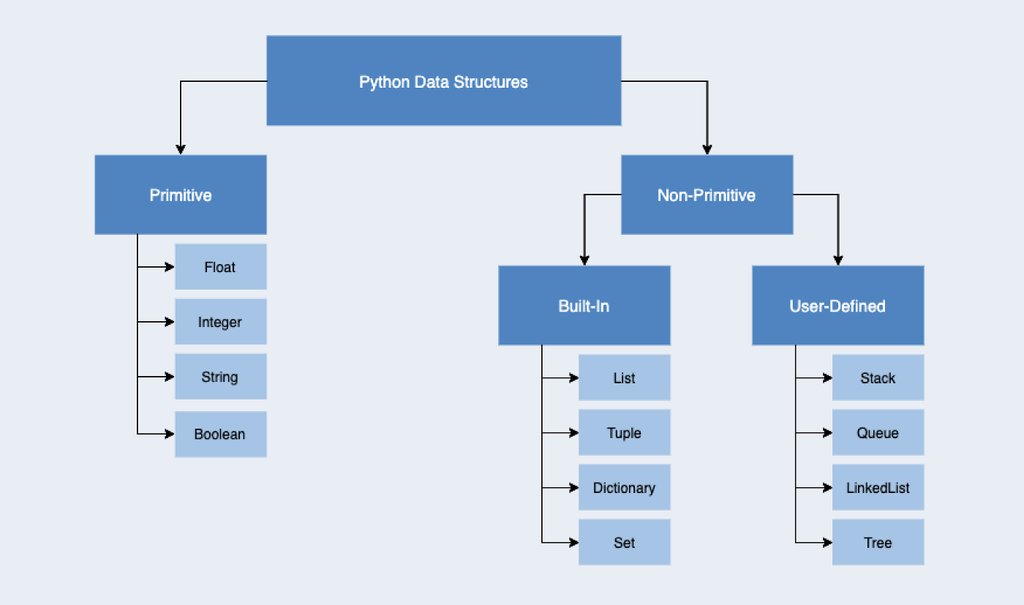

##### **1. Primitive Data Structures**

###### **a. Float or Floating Point**

**A floating point (known as a float) number** has decimal points even if that decimal point value is 0. Such as, 8.85 , 458.001 or 521.10002 for example.

```python
floating_point = 11.0
print(floating_point)
print(type(floating_point))
```

```
11.0
<class 'float'>
```

###### **b. Integer**

**An integer** does not have a decimal point. If we are willing to use 45.99 as an integer, it would be stored as 45. Such as, in integer types 9999.999 would be stored as 9999 or 10.0000000001 would be stored as 10, for example. **Note:** You will often see the data type **Int64** in Python which stands for 64 bit integer. The 64 refers to the memory allocated to store data in each cell which effectively relates to how many digits it can store in each “cell”. Allocating space ahead of time allows computers to optimize storage and processing efficiency. [Reference](https://datacarpentry.org/python-ecology-lesson/04-data-types-and-format/#numeric-data-types) [For more knowledge](https://jakevdp.github.io/PythonDataScienceHandbook/02.01-understanding-data-types.html)

```python
integer = 11
print(integer)
print(type(integer))
```

```
11
<class 'int'>
```

###### **c. Boolean**

In computer science, **the Boolean** (sometimes shortened to **Bool**) is a data type that has one of two possible values (usually denoted true and false) which is intended to represent the two truth values of logic and Boolean algebra. [Reference](https://en.wikipedia.org/wiki/Boolean_data_type)

```python
print(2 > 1)
print(15 == 16)
print(100 < 19)
```

```
True
False
False
```

###### **d. String (Text) Data Types**

**Text data type** is known as **Strings in Python**, or **Objects in Pandas**. Strings can contain numbers and / or characters. For example, a string might be a word, a sentence, or several sentences. Note: Strings that contain numbers can not be used for mathematical operations!!! [Reference](https://datacarpentry.org/python-ecology-lesson/04-data-types-and-format/#numeric-data-types)

```python
text_data_types = "1,2,"'DATA'""
print(text_data_types)
print(type(text_data_types))
```

```
1,2,DATA
<class 'str'>
```

##### **2. Non - Primitive Data Structures**

###### **2.1 Built-In Data Structures**

###### **a. List**

**A list** in Python is a collection of items which can contain elements of multiple data types, which may be either numeric, character logical values, etc. [Reference](https://www.geeksforgeeks.org/difference-between-list-and-array-in-python/) Lists have a number of important characteristics: 1. List items are **enclosed** in square brackets, like this [item1, item2, item3]. 2. Lists are **ordered** – i.e. the items in the list appear in a specific order. This enables us to use an index to access to any item. 3. Lists are **mutable**, which means you can add or remove items after a list's creation. 4. List elements **do not need to be unique**. Item duplication is possible, as each element has its own distinct place and can be accessed separately through the index. 5. Elements can be of **different data types**: you can combine strings, integers, and objects in the same list. [Reference](https://learnpython.com/blog/python-array-vs-list/)

```python
List_example_1 = [1,2.72,3,'Zurich','Toronto','San Francisco',True]

print(List_example_1)
print(type(List_example_1))
```

```
[1, 2.72, 3, 'Zurich', 'Toronto', 'San Francisco', True]
<class 'list'>
```

###### **b. Tuple**

**Tuples** are used to store multiple items in a single variable. A tuple is a collection which is **ordered** and **unchangeable/immutable**. A tuple can have any number of items and they may be of different types (**integer, float, list, string, etc.**). Tuples are written with **round brackets**. [Reference](https://www.w3schools.com/python/python_tuples.asp) [Reference](https://www.programiz.com/python-programming/tuple)

```python
Tuple_example_1 = (1,2,3,'Toronto','Zurich','Paris')
print(Tuple_example_1)
print(type(Tuple_example_1))
```

```
(1, 2, 3, 'Toronto', 'Zurich', 'Paris')
<class 'tuple'>
```

###### **c. Dictionary**

**Dictionaries** are used to store data values in key:value pairs. A dictionary, which is **ordered, changeable and do not allow duplicates**, is a collection.[Reference](https://www.w3schools.com/python/python_dictionaries.asp) Creating a dictionary is as simple as placing items inside **curly braces {}** separated by commas. An item has a key and a corresponding value that is expressed as **a pair (key: value)**.[Reference](https://www.programiz.com/python-programming/dictionary) **Note:** As of Python version 3.7, dictionaries are **ordered**. In Python 3.6 and earlier, dictionaries are unordered. [Reference](https://www.w3schools.com/python/python_dictionaries.asp)

```python
Dictionary_example = {'City':['Zurich','Toronto'],
                      'Country':['Swiss','Canada'],
                      'Continental':['Europa','North America']}
print(Dictionary_example)
print(type(Dictionary_example))
```

```
{'City': ['Zurich', 'Toronto'], 'Country': ['Swiss', 'Canada'], 'Continental': ['Europa', 'North America']}
<class 'dict'>
```

###### **d. Set**

**A set** is an unordered collection of items. Every set element is **unique (no duplicates)** and must be **immutable (cannot be changed)** and **unindexed**. However, a set itself is mutable. We can **add** or **remove** items from it. Sets can also be used to perform **mathematical** set operations like union, intersection, symmetric difference, etc. It can have any number of items and they may be of **different types (integer, float, tuple, string etc.)**. But a set cannot have mutable elements like lists, sets or dictionaries as its elements.

```python
Set_example = {1,2,3,'Basel',1.1}
print(Set_example)
print(type(Set_example))
```

```
{1, 2, 3, 1.1, 'Basel'}
<class 'set'>
```

###### **The Summary of Data Structures' Features**

[output not shown]

### **B. Data Structures in Pandas**

A data structure is a collection of data values and defines the relationship between the data, and the operations that can be performed on the data. There are three main data structures in pandas: - 1. Series - 1D - 2. DataFrame - 2D - 3. Panel - 3D [Reference](https://medium.com/data-science-365/pandas-for-data-science-part-1-89bc231b3478)

#### **1. Series - 1D**

One-dimensional ndarray with axis labels (including time series). [Reference](https://pandas.pydata.org/docs/reference/api/pandas.Series.html)

```python
import pandas as pd
import numpy as np
```

```python
series = {'a':[1,11], 'b':[2,22], 'c':[3,33]}

pandas_series = pd.Series(series)
print(pandas_series)

print(type(pandas_series))
```

```
a    [1, 11]
b    [2, 22]
c    [3, 33]
dtype: object
<class 'pandas.core.series.Series'>
```

#### **2. DataFrame - 2D**

Two-dimensional, size-mutable, potentially heterogeneous tabular data. [Reference](https://pandas.pydata.org/docs/reference/api/pandas.DataFrame.html)

```python
pandas_dataframe = pd.DataFrame(series)
pandas_dataframe
```

|  | a | b | c |
| --- | --- | --- | --- |
| 0 | 1 | 2 | 3 |
| 1 | 11 | 22 | 33 |

```python
type(pandas_dataframe)
```

```
pandas.core.frame.DataFrame
```

#### **3. Panel - 3D**

Represents wide format panel data, stored as 3-dimensional array. [Reference](https://pandas.pydata.org/pandas-docs/version/0.23/generated/pandas.Panel.html) Panel is deprecated. Hence, the recommended way to represent these types of 3-dimensional data is to use multi-indexing in DataFrames instead of Panels. A multi-indexed DataFrame can be directly converted to a Panel via DataFrame.to_panel() method. [Reference](https://medium.com/data-science-365/pandas-for-data-science-part-1-89bc231b3478) [Reference](https://pandas.pydata.org/docs/reference/api/pandas.MultiIndex.html) [Reference](https://pandas.pydata.org/docs/user_guide/advanced.html) Note: The panel has been removed from Pandas module 0.25.0 onwards. [Reference](https://www.geeksforgeeks.org/python-pandas-panel-shape/)

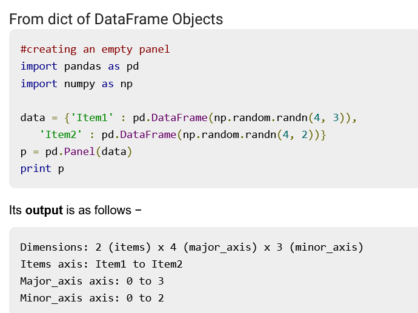

[For more knowledge](https://www.tutorialspoint.com/python_pandas/python_pandas_panel.htm)

## 2 - Reading CSV Files

Import Pandas Library and label it as 'pd'

```python
import pandas as pd
```

In this part, you need to download the dataset. Keep in mind where the file is on your computer because as we need to specify the location of the file in Jupyter notebook in order to load the data. [dataset](https://github.com/hasan-firat-data-and-business-analyst/Data-Science-Python/blob/main/auto.csv).

```python
reading_csv_files_example = pd.read_csv(r'auto.csv')
```

'head()' shows the first five rows of the dataframe by default but you can specify the number of rows in the parenthesis.

```python
reading_csv_files_example.head()
```

|  | symboling | normalized-losses | make | fuel-type | aspiration | num-of-doors | body-style | drive-wheels | engine-location | wheel-base | ... | engine-size | fuel-system | bore | stroke | compression-ratio | horsepower | peak-rpm | city-mpg | highway-mpg | price |
| --- | --- | --- | --- | --- | --- | --- | --- | --- | --- | --- | --- | --- | --- | --- | --- | --- | --- | --- | --- | --- | --- |
| 0 | 3 | 122.0 | alfa-romero | gas | std | two | convertible | rwd | front | 88.6 | ... | 130 | mpfi | 3.47 | 2.68 | 9.0 | 111.0 | 5000.0 | 21 | 27 | 13495 |
| 1 | 3 | 122.0 | alfa-romero | gas | std | two | convertible | rwd | front | 88.6 | ... | 130 | mpfi | 3.47 | 2.68 | 9.0 | 111.0 | 5000.0 | 21 | 27 | 16500 |
| 2 | 1 | 122.0 | alfa-romero | gas | std | two | hatchback | rwd | front | 94.5 | ... | 152 | mpfi | 2.68 | 3.47 | 9.0 | 154.0 | 5000.0 | 19 | 26 | 16500 |
| 3 | 2 | 164.0 | audi | gas | std | four | sedan | fwd | front | 99.8 | ... | 109 | mpfi | 3.19 | 3.40 | 10.0 | 102.0 | 5500.0 | 24 | 30 | 13950 |
| 4 | 2 | 164.0 | audi | gas | std | four | sedan | 4wd | front | 99.4 | ... | 136 | mpfi | 3.19 | 3.40 | 8.0 | 115.0 | 5500.0 | 18 | 22 | 17450 |

5 rows × 26 columns

'tail()' shows the bottom five rows by default.

```python
reading_csv_files_example.tail()
```

|  | symboling | normalized-losses | make | fuel-type | aspiration | num-of-doors | body-style | drive-wheels | engine-location | wheel-base | ... | engine-size | fuel-system | bore | stroke | compression-ratio | horsepower | peak-rpm | city-mpg | highway-mpg | price |
| --- | --- | --- | --- | --- | --- | --- | --- | --- | --- | --- | --- | --- | --- | --- | --- | --- | --- | --- | --- | --- | --- |
| 196 | -1 | 95.0 | volvo | gas | std | four | sedan | rwd | front | 109.1 | ... | 141 | mpfi | 3.78 | 3.15 | 9.5 | 114.0 | 5400.0 | 23 | 28 | 16845 |
| 197 | -1 | 95.0 | volvo | gas | turbo | four | sedan | rwd | front | 109.1 | ... | 141 | mpfi | 3.78 | 3.15 | 8.7 | 160.0 | 5300.0 | 19 | 25 | 19045 |
| 198 | -1 | 95.0 | volvo | gas | std | four | sedan | rwd | front | 109.1 | ... | 173 | mpfi | 3.58 | 2.87 | 8.8 | 134.0 | 5500.0 | 18 | 23 | 21485 |
| 199 | -1 | 95.0 | volvo | diesel | turbo | four | sedan | rwd | front | 109.1 | ... | 145 | idi | 3.01 | 3.40 | 23.0 | 106.0 | 4800.0 | 26 | 27 | 22470 |
| 200 | -1 | 95.0 | volvo | gas | turbo | four | sedan | rwd | front | 109.1 | ... | 141 | mpfi | 3.78 | 3.15 | 9.5 | 114.0 | 5400.0 | 19 | 25 | 22625 |

5 rows × 26 columns

we are good to use in the function of 'head()' and 'tail()' in any numbers.

```python
reading_csv_files_example.head(3)
```

|  | symboling | normalized-losses | make | fuel-type | aspiration | num-of-doors | body-style | drive-wheels | engine-location | wheel-base | ... | engine-size | fuel-system | bore | stroke | compression-ratio | horsepower | peak-rpm | city-mpg | highway-mpg | price |
| --- | --- | --- | --- | --- | --- | --- | --- | --- | --- | --- | --- | --- | --- | --- | --- | --- | --- | --- | --- | --- | --- |
| 0 | 3 | 122.0 | alfa-romero | gas | std | two | convertible | rwd | front | 88.6 | ... | 130 | mpfi | 3.47 | 2.68 | 9.0 | 111.0 | 5000.0 | 21 | 27 | 13495 |
| 1 | 3 | 122.0 | alfa-romero | gas | std | two | convertible | rwd | front | 88.6 | ... | 130 | mpfi | 3.47 | 2.68 | 9.0 | 111.0 | 5000.0 | 21 | 27 | 16500 |
| 2 | 1 | 122.0 | alfa-romero | gas | std | two | hatchback | rwd | front | 94.5 | ... | 152 | mpfi | 2.68 | 3.47 | 9.0 | 154.0 | 5000.0 | 19 | 26 | 16500 |

3 rows × 26 columns

```python
reading_csv_files_example.tail(7)
```

|  | symboling | normalized-losses | make | fuel-type | aspiration | num-of-doors | body-style | drive-wheels | engine-location | wheel-base | ... | engine-size | fuel-system | bore | stroke | compression-ratio | horsepower | peak-rpm | city-mpg | highway-mpg | price |
| --- | --- | --- | --- | --- | --- | --- | --- | --- | --- | --- | --- | --- | --- | --- | --- | --- | --- | --- | --- | --- | --- |
| 194 | -2 | 103.0 | volvo | gas | turbo | four | sedan | rwd | front | 104.3 | ... | 130 | mpfi | 3.62 | 3.15 | 7.5 | 162.0 | 5100.0 | 17 | 22 | 18420 |
| 195 | -1 | 74.0 | volvo | gas | turbo | four | wagon | rwd | front | 104.3 | ... | 130 | mpfi | 3.62 | 3.15 | 7.5 | 162.0 | 5100.0 | 17 | 22 | 18950 |
| 196 | -1 | 95.0 | volvo | gas | std | four | sedan | rwd | front | 109.1 | ... | 141 | mpfi | 3.78 | 3.15 | 9.5 | 114.0 | 5400.0 | 23 | 28 | 16845 |
| 197 | -1 | 95.0 | volvo | gas | turbo | four | sedan | rwd | front | 109.1 | ... | 141 | mpfi | 3.78 | 3.15 | 8.7 | 160.0 | 5300.0 | 19 | 25 | 19045 |
| 198 | -1 | 95.0 | volvo | gas | std | four | sedan | rwd | front | 109.1 | ... | 173 | mpfi | 3.58 | 2.87 | 8.8 | 134.0 | 5500.0 | 18 | 23 | 21485 |
| 199 | -1 | 95.0 | volvo | diesel | turbo | four | sedan | rwd | front | 109.1 | ... | 145 | idi | 3.01 | 3.40 | 23.0 | 106.0 | 4800.0 | 26 | 27 | 22470 |
| 200 | -1 | 95.0 | volvo | gas | turbo | four | sedan | rwd | front | 109.1 | ... | 141 | mpfi | 3.78 | 3.15 | 9.5 | 114.0 | 5400.0 | 19 | 25 | 22625 |

7 rows × 26 columns

'shape' function tells us how many rows and columns exist in a dataframe.

```python
reading_csv_files_example.shape
```

```
(201, 26)
```

## 3 - Pandas DataFrame

### 3.1 - Data Structure Transformation in Pandas

#### 3.1.1 - Dictionary to DataFrame

Checking the Pandas Version out

```python
print(pd.__version__)
```

```
1.2.4
```

Creating dictionary for using in the example and checking the data structure's type of example out

```python
dict_example = { 'Country': ["Canada", "Germany", "Japan"],
               'Continent': ["North America", "Europe", "Asia"]}
```

```python
print(dict_example)
print(type(dict_example))
```

```
{'Country': ['Canada', 'Germany', 'Japan'], 'Continent': ['North America', 'Europe', 'Asia']}
<class 'dict'>
```

Changing types of dictionary to Pandas DataFrame and checking out the last data structure

```python
dictionary_to_df = pd.DataFrame(dict_example)
dictionary_to_df
```

|  | Country | Continent |
| --- | --- | --- |
| 0 | Canada | North America |
| 1 | Germany | Europe |
| 2 | Japan | Asia |

```python
type(dictionary_to_df)
```

```
pandas.core.frame.DataFrame
```

#### 3.1.2 - Dictionary to Pandas Series

Creating the new dictionary for new example

```python
dict_example_for_Pandas_Series = {'Name': ["John","Sebastian","Rayn"],
                                 'Place': ["London", "Vienna","Oslo"]}

print(dict_example_for_Pandas_Series)
print(type(dict_example_for_Pandas_Series))
```

```
{'Name': ['John', 'Sebastian', 'Rayn'], 'Place': ['London', 'Vienna', 'Oslo']}
<class 'dict'>
```

Changing the dictionary data structure to Pandas Series

```python
dictionary_to_series = pd.Series(dict_example_for_Pandas_Series)

print(dictionary_to_series)
print(type(dictionary_to_series))
```

```
Name     [John, Sebastian, Rayn]
Place     [London, Vienna, Oslo]
dtype: object
<class 'pandas.core.series.Series'>
```

#### 3.1.3 - List to DataFrame

Creating the list with only number elements

```python
list_example = [1,2,3,4,5,6,7,8,9]

print(list_example)
print(type(list_example))
```

```
[1, 2, 3, 4, 5, 6, 7, 8, 9]
<class 'list'>
```

Transformation of the list to Pandas DataFrame

```python
list_example_df = pd.DataFrame(list_example)
```

```python
list_example_df
```

|  | 0 |
| --- | --- |
| 0 | 1 |
| 1 | 2 |
| 2 | 3 |
| 3 | 4 |
| 4 | 5 |
| 5 | 6 |
| 6 | 7 |
| 7 | 8 |
| 8 | 9 |

```python
type(list_example_df)
```

```
pandas.core.frame.DataFrame
```

Creating the other list with both numbers and string elements

```python
list_example2 = [1,2,3,4,"Zurich"]

list_example2
```

```
[1, 2, 3, 4, 'Zurich']
```

The transformation of the new list to Pandas DataFrame

```python
list_example_df2 = pd.DataFrame(list_example2)
list_example_df2
```

|  | 0 |
| --- | --- |
| 0 | 1 |
| 1 | 2 |
| 2 | 3 |
| 3 | 4 |
| 4 | Zurich |

```python
type(list_example_df2)
```

```
pandas.core.frame.DataFrame
```

#### 3.1.4 - List to Pandas Series

Creating the new list with only numbers

```python
list_example_for_series = [11,22,33,44,55,66,77,88,99]

print(list_example_for_series)
print(type(list_example_for_series))
```

```
[11, 22, 33, 44, 55, 66, 77, 88, 99]
<class 'list'>
```

The list to Pandas Series

```python
list_to_series = pd.Series(list_example_for_series)

print(list_to_series)
print(type(list_to_series))
```

```
0    11
1    22
2    33
3    44
4    55
5    66
6    77
7    88
8    99
dtype: int64
<class 'pandas.core.series.Series'>
```

Creating the other list with numbers and strings

```python
list_example_for_series2 = [11,22,33,"Asia","Africa"]

print(list_example_for_series2)
print(type(list_example_for_series2))
```

```
[11, 22, 33, 'Asia', 'Africa']
<class 'list'>
```

List to Pandas Series

```python
list_to_series2 = pd.Series(list_example_for_series2)

print(list_to_series2)
print(type(list_to_series2))
```

```
0        11
1        22
2        33
3      Asia
4    Africa
dtype: object
<class 'pandas.core.series.Series'>
```

### 3.2 Creating the Pandas DataFrame

#### 3.2.1 - Text Dataframe

```python
dict_for_dataframe_text = {'Name':["Carlos","David","Emma"],
                           'City':["New York","Tokyo","Berlin"]}

pandas_dataframe_example_text = pd.DataFrame(dict_for_dataframe_text, index = ['User 1','User 2','User 3'])

pandas_dataframe_example_text
```

|  | Name | City |
| --- | --- | --- |
| User 1 | Carlos | New York |
| User 2 | David | Tokyo |
| User 3 | Emma | Berlin |

#### 3.2.2 - The First Way

```python
pandas_dataframe_example = pd.DataFrame({'ID':  [100,101,102,103],
                                         'Math':[99,76,88,98],
                                         'Geo': [78,98,90,89],
                                         'Literature':[98,87,76,77]
                                        })

pandas_dataframe_example
```

|  | ID | Math | Geo | Literature |
| --- | --- | --- | --- | --- |
| 0 | 100 | 99 | 78 | 98 |
| 1 | 101 | 76 | 98 | 87 |
| 2 | 102 | 88 | 90 | 76 |
| 3 | 103 | 98 | 89 | 77 |

#### 3.2.3 - The Second Way

```python
dict_for_dataframe = {'ID':[100,101,102,103],'Math':[99,76,88,98],'Geo': [78,98,90,89],'Literature':[98,87,76,77]}

pandas_dataframe_example2 = pd.DataFrame(dict_for_dataframe)
pandas_dataframe_example2
```

|  | ID | Math | Geo | Literature |
| --- | --- | --- | --- | --- |
| 0 | 100 | 99 | 78 | 98 |
| 1 | 101 | 76 | 98 | 87 |
| 2 | 102 | 88 | 90 | 76 |
| 3 | 103 | 98 | 89 | 77 |

#### 3.2.4 - The Third Way

```python
import numpy as np
pandas_dataframe_example3 = pd.DataFrame([[100,99,78,98],[101,76,98,87],[102,88,90,76],[103,98,89,77]],
                                         columns =['ID','Math','Geo','Literature'],index = np.random.rand(4))

pandas_dataframe_example3
```

|  | ID | Math | Geo | Literature |
| --- | --- | --- | --- | --- |
| 0.333086 | 100 | 99 | 78 | 98 |
| 0.788754 | 101 | 76 | 98 | 87 |
| 0.432543 | 102 | 88 | 90 | 76 |
| 0.333622 | 103 | 98 | 89 | 77 |

#### 3.2.5 - Using Orient Index and Columns

```python
dict_for_dataframe2 = {'ID':[100,101,102,103],'Math':[99,76,88,98],'Geo': [78,98,90,89],'Literature':[98,87,76,77]}
pandas_dataframe_example4 = pd.DataFrame.from_dict(dict_for_dataframe2,orient = 'columns')
pandas_dataframe_example4
```

|  | ID | Math | Geo | Literature |
| --- | --- | --- | --- | --- |
| 0 | 100 | 99 | 78 | 98 |
| 1 | 101 | 76 | 98 | 87 |
| 2 | 102 | 88 | 90 | 76 |
| 3 | 103 | 98 | 89 | 77 |

```python
dict_for_dataframe2 = {'ID':[100,101,102,103],'Math':[99,76,88,98],'Geo': [78,98,90,89],'Literature':[98,87,76,77]}
pandas_dataframe_example4 = pd.DataFrame.from_dict(dict_for_dataframe2,orient = 'index')
pandas_dataframe_example4
```

|  | 0 | 1 | 2 | 3 |
| --- | --- | --- | --- | --- |
| ID | 100 | 101 | 102 | 103 |
| Math | 99 | 76 | 88 | 98 |
| Geo | 78 | 98 | 90 | 89 |
| Literature | 98 | 87 | 76 | 77 |

### 3.3 The Columns in Pandas

#### 3.3.1 - Creating The DataFrame Example

```python
dict_for_dataframe = {'ID':[100,101,102,103],'Math':[99,76,88,98],'Geo': [78,98,90,89],'Literature':[98,87,76,77]}

dataframe_column_example = pd.DataFrame(dict_for_dataframe)
dataframe_column_example
```

|  | ID | Math | Geo | Literature |
| --- | --- | --- | --- | --- |
| 0 | 100 | 99 | 78 | 98 |
| 1 | 101 | 76 | 98 | 87 |
| 2 | 102 | 88 | 90 | 76 |
| 3 | 103 | 98 | 89 | 77 |

#### 3.3.2 - Renaming The Columns

```python
renanaming_column_example = dataframe_column_example.rename(columns = {'Geo': 'Geography'}  )

renanaming_column_example
```

|  | ID | Math | Geography | Literature |
| --- | --- | --- | --- | --- |
| 0 | 100 | 99 | 78 | 98 |
| 1 | 101 | 76 | 98 | 87 |
| 2 | 102 | 88 | 90 | 76 |
| 3 | 103 | 98 | 89 | 77 |

#### 3.3.3 - Dropping The Columns

```python
dropping_example = dataframe_column_example.drop(columns = 'Literature')

dropping_example
```

|  | ID | Math | Geo |
| --- | --- | --- | --- |
| 0 | 100 | 99 | 78 |
| 1 | 101 | 76 | 98 |
| 2 | 102 | 88 | 90 |
| 3 | 103 | 98 | 89 |

#### 3.3.4 - Adding The Columns

```python
dataframe_column_example['Data Science'] = [99,96,94,100]

dataframe_column_example
```

|  | ID | Math | Geo | Literature | Data Science |
| --- | --- | --- | --- | --- | --- |
| 0 | 100 | 99 | 78 | 98 | 99 |
| 1 | 101 | 76 | 98 | 87 | 96 |
| 2 | 102 | 88 | 90 | 76 | 94 |
| 3 | 103 | 98 | 89 | 77 | 100 |

### 3.4 - Index in Pandas and Indexing

#### 3.4.1 - Creating the New DataFrame

```python
dataframe_index_example = pd.DataFrame({

    'Name':["Emma","Maddy","Cassy","Tony","Montana","Carl"],
    'Location':["Toronto","Toronto","Zurich","Zurich","New York","Zurich"],
    'Sex':["Female","Female","Female","Male","Male","Male"],
    'Education':['PhD','Bachelor','Master','PhD','Master','Postgrad'],
    'Marital Status':['Single','Married','Divorced','Divorced','Single','Married'],
    'Profession':['Teacher','Lawyer','Engineer','Medical Doctor','Nurse','Business Owner'],
    'Annual Revenue - USD':[100000, 456000,768000,560000,240000,7600000],
    'Children Status':["yes","yes","no","yes","yes","yes"],
    'The Number of Children':[1,1,2,4,2,3],
    'Far from home - km':[124,36,85,777,25,12]

                                       })

dataframe_index_example
```

|  | Name | Location | Sex | Education | Marital Status | Profession | Annual Revenue - USD | Children Status | The Number of Children | Far from home - km |
| --- | --- | --- | --- | --- | --- | --- | --- | --- | --- | --- |
| 0 | Emma | Toronto | Female | PhD | Single | Teacher | 100000 | yes | 1 | 124 |
| 1 | Maddy | Toronto | Female | Bachelor | Married | Lawyer | 456000 | yes | 1 | 36 |
| 2 | Cassy | Zurich | Female | Master | Divorced | Engineer | 768000 | no | 2 | 85 |
| 3 | Tony | Zurich | Male | PhD | Divorced | Medical Doctor | 560000 | yes | 4 | 777 |
| 4 | Montana | New York | Male | Master | Single | Nurse | 240000 | yes | 2 | 25 |
| 5 | Carl | Zurich | Male | Postgrad | Married | Business Owner | 7600000 | yes | 3 | 12 |

#### 3.4.2 - Set Index

To set a column as index for a DataFrame, use DataFrame.set_index() function, with the column name passed as argument. Pandas DataFrame - Set Column as Index You can also setup MultiIndex with multiple columns in the index. In this case, pass the array of column names required for index, to set_index() method. [Reference](https://pythonexamples.org/pandas-set-column-as-index/)

Set Index Example

```python
dataframe_index_example2 = dataframe_index_example.set_index('The Number of Children' )
dataframe_index_example2
```

| The Number of Children | Name | Location | Sex | Education | Marital Status | Profession | Annual Revenue - USD | Children Status | Far from home - km |
| --- | --- | --- | --- | --- | --- | --- | --- | --- | --- |
| 1 | Emma | Toronto | Female | PhD | Single | Teacher | 100000 | yes | 124 |
| 1 | Maddy | Toronto | Female | Bachelor | Married | Lawyer | 456000 | yes | 36 |
| 2 | Cassy | Zurich | Female | Master | Divorced | Engineer | 768000 | no | 85 |
| 4 | Tony | Zurich | Male | PhD | Divorced | Medical Doctor | 560000 | yes | 777 |
| 2 | Montana | New York | Male | Master | Single | Nurse | 240000 | yes | 25 |
| 3 | Carl | Zurich | Male | Postgrad | Married | Business Owner | 7600000 | yes | 12 |

Set Index Example

```python
dataframe_index_example3 = dataframe_index_example.set_index((dataframe_index_example['The Number of Children'] == 2) )
dataframe_index_example3
```

| The Number of Children | Name | Location | Sex | Education | Marital Status | Profession | Annual Revenue - USD | Children Status | The Number of Children | Far from home - km |
| --- | --- | --- | --- | --- | --- | --- | --- | --- | --- | --- |
| False | Emma | Toronto | Female | PhD | Single | Teacher | 100000 | yes | 1 | 124 |
| False | Maddy | Toronto | Female | Bachelor | Married | Lawyer | 456000 | yes | 1 | 36 |
| True | Cassy | Zurich | Female | Master | Divorced | Engineer | 768000 | no | 2 | 85 |
| False | Tony | Zurich | Male | PhD | Divorced | Medical Doctor | 560000 | yes | 4 | 777 |
| True | Montana | New York | Male | Master | Single | Nurse | 240000 | yes | 2 | 25 |
| False | Carl | Zurich | Male | Postgrad | Married | Business Owner | 7600000 | yes | 3 | 12 |

Set Index Example

```python
dataframe_index_example4 = dataframe_index_example.set_index((dataframe_index_example['Children Status'] == 'yes') )
dataframe_index_example4
```

| Children Status | Name | Location | Sex | Education | Marital Status | Profession | Annual Revenue - USD | Children Status | The Number of Children | Far from home - km |
| --- | --- | --- | --- | --- | --- | --- | --- | --- | --- | --- |
| True | Emma | Toronto | Female | PhD | Single | Teacher | 100000 | yes | 1 | 124 |
| True | Maddy | Toronto | Female | Bachelor | Married | Lawyer | 456000 | yes | 1 | 36 |
| False | Cassy | Zurich | Female | Master | Divorced | Engineer | 768000 | no | 2 | 85 |
| True | Tony | Zurich | Male | PhD | Divorced | Medical Doctor | 560000 | yes | 4 | 777 |
| True | Montana | New York | Male | Master | Single | Nurse | 240000 | yes | 2 | 25 |
| True | Carl | Zurich | Male | Postgrad | Married | Business Owner | 7600000 | yes | 3 | 12 |

Set Index Example

```python
dataframe_set_index_example5 = dataframe_index_example.set_index(['Education','Location'])
dataframe_set_index_example5
```

| Education | Location | Name | Sex | Marital Status | Profession | Annual Revenue - USD | Children Status | The Number of Children | Far from home - km |
| --- | --- | --- | --- | --- | --- | --- | --- | --- | --- |
| PhD | Toronto | Emma | Female | Single | Teacher | 100000 | yes | 1 | 124 |
| Bachelor | Toronto | Maddy | Female | Married | Lawyer | 456000 | yes | 1 | 36 |
| Master | Zurich | Cassy | Female | Divorced | Engineer | 768000 | no | 2 | 85 |
| PhD | Zurich | Tony | Male | Divorced | Medical Doctor | 560000 | yes | 4 | 777 |
| Master | New York | Montana | Male | Single | Nurse | 240000 | yes | 2 | 25 |
| Postgrad | Zurich | Carl | Male | Married | Business Owner | 7600000 | yes | 3 | 12 |

Set Index Example

```python
dataframe_set_index_example6 = dataframe_index_example.set_index(
    ['Marital Status',
    dataframe_index_example['Annual Revenue - USD'] > 300000])

dataframe_set_index_example6
```

| Marital Status | Annual Revenue - USD | Name | Location | Sex | Education | Profession | Annual Revenue - USD | Children Status | The Number of Children | Far from home - km |
| --- | --- | --- | --- | --- | --- | --- | --- | --- | --- | --- |
| Single | False | Emma | Toronto | Female | PhD | Teacher | 100000 | yes | 1 | 124 |
| Married | True | Maddy | Toronto | Female | Bachelor | Lawyer | 456000 | yes | 1 | 36 |
| Divorced | True | Cassy | Zurich | Female | Master | Engineer | 768000 | no | 2 | 85 |
|  | True | Tony | Zurich | Male | PhD | Medical Doctor | 560000 | yes | 4 | 777 |
| Single | False | Montana | New York | Male | Master | Nurse | 240000 | yes | 2 | 25 |
| Married | True | Carl | Zurich | Male | Postgrad | Business Owner | 7600000 | yes | 3 | 12 |

Set Index Example

```python
dataframe_set_index_example7 = dataframe_index_example.set_index(
    ['Marital Status',
    dataframe_index_example['Annual Revenue - USD'] > 300000,'Location'])

dataframe_set_index_example7
```

| Marital Status | Annual Revenue - USD | Location | Name | Sex | Education | Profession | Annual Revenue - USD | Children Status | The Number of Children | Far from home - km |
| --- | --- | --- | --- | --- | --- | --- | --- | --- | --- | --- |
| Single | False | Toronto | Emma | Female | PhD | Teacher | 100000 | yes | 1 | 124 |
| Married | True | Toronto | Maddy | Female | Bachelor | Lawyer | 456000 | yes | 1 | 36 |
| Divorced | True | Zurich | Cassy | Female | Master | Engineer | 768000 | no | 2 | 85 |
|  |  | Zurich | Tony | Male | PhD | Medical Doctor | 560000 | yes | 4 | 777 |
| Single | False | New York | Montana | Male | Master | Nurse | 240000 | yes | 2 | 25 |
| Married | True | Zurich | Carl | Male | Postgrad | Business Owner | 7600000 | yes | 3 | 12 |

```python
dataframe_set_index_example8 = dataframe_index_example.set_index(
    ['Marital Status',
    dataframe_index_example['Annual Revenue - USD'] > 300000,
     'Location',
    dataframe_index_example['Far from home - km'] > 75
    ])

dataframe_set_index_example8
```

| Marital Status | Annual Revenue - USD | Location | Far from home - km | Name | Sex | Education | Profession | Annual Revenue - USD | Children Status | The Number of Children | Far from home - km |
| --- | --- | --- | --- | --- | --- | --- | --- | --- | --- | --- | --- |
| Single | False | Toronto | True | Emma | Female | PhD | Teacher | 100000 | yes | 1 | 124 |
| Married | True | Toronto | False | Maddy | Female | Bachelor | Lawyer | 456000 | yes | 1 | 36 |
| Divorced | True | Zurich | True | Cassy | Female | Master | Engineer | 768000 | no | 2 | 85 |
|  |  |  | True | Tony | Male | PhD | Medical Doctor | 560000 | yes | 4 | 777 |
| Single | False | New York | False | Montana | Male | Master | Nurse | 240000 | yes | 2 | 25 |
| Married | True | Zurich | False | Carl | Male | Postgrad | Business Owner | 7600000 | yes | 3 | 12 |

Set Index Example

NOTE: If we do not use ' [ ] ' (square brackets) with multiple column selection, as you are able to see on the below example, we can get only the first columns name, which is written in the set_index function.

```python
dataframe_set_index_example9 = dataframe_index_example.set_index('Sex','Location')
dataframe_set_index_example9
```

| Sex | Name | Location | Education | Marital Status | Profession | Annual Revenue - USD | Children Status | The Number of Children | Far from home - km |
| --- | --- | --- | --- | --- | --- | --- | --- | --- | --- |
| Female | Emma | Toronto | PhD | Single | Teacher | 100000 | yes | 1 | 124 |
| Female | Maddy | Toronto | Bachelor | Married | Lawyer | 456000 | yes | 1 | 36 |
| Female | Cassy | Zurich | Master | Divorced | Engineer | 768000 | no | 2 | 85 |
| Male | Tony | Zurich | PhD | Divorced | Medical Doctor | 560000 | yes | 4 | 777 |
| Male | Montana | New York | Master | Single | Nurse | 240000 | yes | 2 | 25 |
| Male | Carl | Zurich | Postgrad | Married | Business Owner | 7600000 | yes | 3 | 12 |

#### 3.4.3 - Dropping the Rows

The drop() function is used to drop specified labels from rows or columns. Remove rows or columns by specifying label names and corresponding axis, or by specifying directly index or column names. When using a multi-index, labels on different levels can be removed by specifying the level. [Reference](https://www.w3resource.com/pandas/dataframe/dataframe-drop.php) The drop() method removes the specified row or column. By specifying the column axis (axis='columns'), the drop() method removes the specified column. By specifying the row axis (axis='index'), the drop() method removes the specified row. [Reference](https://www.w3schools.com/python/pandas/ref_df_drop.asp)

```python
dataframe_index_example
```

|  | Name | Location | Sex | Education | Marital Status | Profession | Annual Revenue - USD | Children Status | The Number of Children | Far from home - km |
| --- | --- | --- | --- | --- | --- | --- | --- | --- | --- | --- |
| 0 | Emma | Toronto | Female | PhD | Single | Teacher | 100000 | yes | 1 | 124 |
| 1 | Maddy | Toronto | Female | Bachelor | Married | Lawyer | 456000 | yes | 1 | 36 |
| 2 | Cassy | Zurich | Female | Master | Divorced | Engineer | 768000 | no | 2 | 85 |
| 3 | Tony | Zurich | Male | PhD | Divorced | Medical Doctor | 560000 | yes | 4 | 777 |
| 4 | Montana | New York | Male | Master | Single | Nurse | 240000 | yes | 2 | 25 |
| 5 | Carl | Zurich | Male | Postgrad | Married | Business Owner | 7600000 | yes | 3 | 12 |

Dropping the row

```python
dataframe_index_dropping_example6 = dataframe_index_example.drop(0)
dataframe_index_dropping_example6
```

|  | Name | Location | Sex | Education | Marital Status | Profession | Annual Revenue - USD | Children Status | The Number of Children | Far from home - km |
| --- | --- | --- | --- | --- | --- | --- | --- | --- | --- | --- |
| 1 | Maddy | Toronto | Female | Bachelor | Married | Lawyer | 456000 | yes | 1 | 36 |
| 2 | Cassy | Zurich | Female | Master | Divorced | Engineer | 768000 | no | 2 | 85 |
| 3 | Tony | Zurich | Male | PhD | Divorced | Medical Doctor | 560000 | yes | 4 | 777 |
| 4 | Montana | New York | Male | Master | Single | Nurse | 240000 | yes | 2 | 25 |
| 5 | Carl | Zurich | Male | Postgrad | Married | Business Owner | 7600000 | yes | 3 | 12 |

Above example, we has dropped the first row, the number of index is 0 (zero). Please, check " dataframe_index_example " example out. NOTE: This method is used for only " ONE ROW ". If you want to add more row or index number for dropping, it needs to be written in " [ ] " square brackets.

```python
dataframe_index_dropping_example6_more_rows = dataframe_index_example.drop([0,2,3])
dataframe_index_dropping_example6_more_rows
```

|  | Name | Location | Sex | Education | Marital Status | Profession | Annual Revenue - USD | Children Status | The Number of Children | Far from home - km |
| --- | --- | --- | --- | --- | --- | --- | --- | --- | --- | --- |
| 1 | Maddy | Toronto | Female | Bachelor | Married | Lawyer | 456000 | yes | 1 | 36 |
| 4 | Montana | New York | Male | Master | Single | Nurse | 240000 | yes | 2 | 25 |
| 5 | Carl | Zurich | Male | Postgrad | Married | Business Owner | 7600000 | yes | 3 | 12 |

NOTE: This method is used for only " ONE ROW ". If you want to add more row or index number, it needs to be written in " [] " square brackets.

Dropping the row

```python
dataframe_index_dropping_example7 = dataframe_index_example.drop(5, axis='index')
dataframe_index_dropping_example7
```

|  | Name | Location | Sex | Education | Marital Status | Profession | Annual Revenue - USD | Children Status | The Number of Children | Far from home - km |
| --- | --- | --- | --- | --- | --- | --- | --- | --- | --- | --- |
| 0 | Emma | Toronto | Female | PhD | Single | Teacher | 100000 | yes | 1 | 124 |
| 1 | Maddy | Toronto | Female | Bachelor | Married | Lawyer | 456000 | yes | 1 | 36 |
| 2 | Cassy | Zurich | Female | Master | Divorced | Engineer | 768000 | no | 2 | 85 |
| 3 | Tony | Zurich | Male | PhD | Divorced | Medical Doctor | 560000 | yes | 4 | 777 |
| 4 | Montana | New York | Male | Master | Single | Nurse | 240000 | yes | 2 | 25 |

In above example, we has dropped the fifth row by using the other way of dropping function, the number of index is 5 (five). Please, check " dataframe_index_example " example out.

```python
dataframe_index_dropping_example8 = dataframe_index_example.drop(index=([1,4,5]))
dataframe_index_dropping_example8
```

|  | Name | Location | Sex | Education | Marital Status | Profession | Annual Revenue - USD | Children Status | The Number of Children | Far from home - km |
| --- | --- | --- | --- | --- | --- | --- | --- | --- | --- | --- |
| 0 | Emma | Toronto | Female | PhD | Single | Teacher | 100000 | yes | 1 | 124 |
| 2 | Cassy | Zurich | Female | Master | Divorced | Engineer | 768000 | no | 2 | 85 |
| 3 | Tony | Zurich | Male | PhD | Divorced | Medical Doctor | 560000 | yes | 4 | 777 |

In the last example, we has dropped the first, fourth and fifth rows by using the dropping function with index, the number of index is 1,4, and 5. Please, check " dataframe_index_example " example out.

Dropping the column

```python
dataframe_index_dropping_example9 = dataframe_index_example.drop("Profession" , axis='columns')
dataframe_index_dropping_example9
```

|  | Name | Location | Sex | Education | Marital Status | Annual Revenue - USD | Children Status | The Number of Children | Far from home - km |
| --- | --- | --- | --- | --- | --- | --- | --- | --- | --- |
| 0 | Emma | Toronto | Female | PhD | Single | 100000 | yes | 1 | 124 |
| 1 | Maddy | Toronto | Female | Bachelor | Married | 456000 | yes | 1 | 36 |
| 2 | Cassy | Zurich | Female | Master | Divorced | 768000 | no | 2 | 85 |
| 3 | Tony | Zurich | Male | PhD | Divorced | 560000 | yes | 4 | 777 |
| 4 | Montana | New York | Male | Master | Single | 240000 | yes | 2 | 25 |
| 5 | Carl | Zurich | Male | Postgrad | Married | 7600000 | yes | 3 | 12 |

In the first dropping column example, we used " axis = 'columns' " in " drop() method " to remove the specified column.

```python
dataframe_index_dropping_example10 = dataframe_index_example.drop(["Children Status", "Education"], axis=1)
dataframe_index_dropping_example10
```

|  | Name | Location | Sex | Marital Status | Profession | Annual Revenue - USD | The Number of Children | Far from home - km |
| --- | --- | --- | --- | --- | --- | --- | --- | --- |
| 0 | Emma | Toronto | Female | Single | Teacher | 100000 | 1 | 124 |
| 1 | Maddy | Toronto | Female | Married | Lawyer | 456000 | 1 | 36 |
| 2 | Cassy | Zurich | Female | Divorced | Engineer | 768000 | 2 | 85 |
| 3 | Tony | Zurich | Male | Divorced | Medical Doctor | 560000 | 4 | 777 |
| 4 | Montana | New York | Male | Single | Nurse | 240000 | 2 | 25 |
| 5 | Carl | Zurich | Male | Married | Business Owner | 7600000 | 3 | 12 |

In the second example to drop the column, we used " drop() method " to remove the "Children Status", and "Education" columns.

```python
dataframe_index_dropping_example11 = dataframe_index_example.drop(columns = ["Sex","Location"])
dataframe_index_dropping_example11
```

|  | Name | Education | Marital Status | Profession | Annual Revenue - USD | Children Status | The Number of Children | Far from home - km |
| --- | --- | --- | --- | --- | --- | --- | --- | --- |
| 0 | Emma | PhD | Single | Teacher | 100000 | yes | 1 | 124 |
| 1 | Maddy | Bachelor | Married | Lawyer | 456000 | yes | 1 | 36 |
| 2 | Cassy | Master | Divorced | Engineer | 768000 | no | 2 | 85 |
| 3 | Tony | PhD | Divorced | Medical Doctor | 560000 | yes | 4 | 777 |
| 4 | Montana | Master | Single | Nurse | 240000 | yes | 2 | 25 |
| 5 | Carl | Postgrad | Married | Business Owner | 7600000 | yes | 3 | 12 |

In the last example, we used " columns = ["_","_"] " in " drop() method " to remove the "Sex", and "Location" columns.

```python
dataframe_index_dropping_example11 = dataframe_index_example.drop(1, axis='index')
dataframe_index_dropping_example11
```

|  | Name | Location | Sex | Education | Marital Status | Profession | Annual Revenue - USD | Children Status | The Number of Children | Far from home - km |
| --- | --- | --- | --- | --- | --- | --- | --- | --- | --- | --- |
| 0 | Emma | Toronto | Female | PhD | Single | Teacher | 100000 | yes | 1 | 124 |
| 2 | Cassy | Zurich | Female | Master | Divorced | Engineer | 768000 | no | 2 | 85 |
| 3 | Tony | Zurich | Male | PhD | Divorced | Medical Doctor | 560000 | yes | 4 | 777 |
| 4 | Montana | New York | Male | Master | Single | Nurse | 240000 | yes | 2 | 25 |
| 5 | Carl | Zurich | Male | Postgrad | Married | Business Owner | 7600000 | yes | 3 | 12 |

Dropping the row and column at the same time

```python
dataframe_index_dropping_example12 = dataframe_index_example.drop(
    index = [1,3,5],
    columns=["Sex","Marital Status", "Annual Revenue - USD"])

dataframe_index_dropping_example12
```

|  | Name | Location | Education | Profession | Children Status | The Number of Children | Far from home - km |
| --- | --- | --- | --- | --- | --- | --- | --- |
| 0 | Emma | Toronto | PhD | Teacher | yes | 1 | 124 |
| 2 | Cassy | Zurich | Master | Engineer | no | 2 | 85 |
| 4 | Montana | New York | Master | Nurse | yes | 2 | 25 |

In this example, we have learned how to drop both the rows and columns at the same time in the same code block. This examples can be extended with the other kind of dropping syntax.

#### 3.4.4 - Adding the Rows

#### Adding the Rows

```python
df_for_adding_example = pd.DataFrame({
    'Name':["Albert"],
    'Location':["London"],
    'Sex':["Male"],
    'Education':["Bachelor"],
    'Marital Status':["Single"],
    'Profession':["Lawyer"],
    'Annual Revenue - USD': [158000],
    'Children Status': ["no"],
    'The Number of Children': [0]
})

df_for_adding_example
```

|  | Name | Location | Sex | Education | Marital Status | Profession | Annual Revenue - USD | Children Status | The Number of Children |
| --- | --- | --- | --- | --- | --- | --- | --- | --- | --- |
| 0 | Albert | London | Male | Bachelor | Single | Lawyer | 158000 | no | 0 |

```python
dataframe_index_adding_example = dataframe_index_example.append(df_for_adding_example,ignore_index=False)
dataframe_index_adding_example
```

|  | Name | Location | Sex | Education | Marital Status | Profession | Annual Revenue - USD | Children Status | The Number of Children | Far from home - km |
| --- | --- | --- | --- | --- | --- | --- | --- | --- | --- | --- |
| 0 | Emma | Toronto | Female | PhD | Single | Teacher | 100000 | yes | 1 | 124.0 |
| 1 | Maddy | Toronto | Female | Bachelor | Married | Lawyer | 456000 | yes | 1 | 36.0 |
| 2 | Cassy | Zurich | Female | Master | Divorced | Engineer | 768000 | no | 2 | 85.0 |
| 3 | Tony | Zurich | Male | PhD | Divorced | Medical Doctor | 560000 | yes | 4 | 777.0 |
| 4 | Montana | New York | Male | Master | Single | Nurse | 240000 | yes | 2 | 25.0 |
| 5 | Carl | Zurich | Male | Postgrad | Married | Business Owner | 7600000 | yes | 3 | 12.0 |
| 0 | Albert | London | Male | Bachelor | Single | Lawyer | 158000 | no | 0 | NaN |

In the above example, if we use " ignore_index " as " False ", the new row, that has added, is shown as " zero (0) " on the last row in the DataFrame.

```python
dataframe_index_adding_example2 = dataframe_index_example.append(df_for_adding_example,ignore_index=True)
dataframe_index_adding_example2
```

|  | Name | Location | Sex | Education | Marital Status | Profession | Annual Revenue - USD | Children Status | The Number of Children | Far from home - km |
| --- | --- | --- | --- | --- | --- | --- | --- | --- | --- | --- |
| 0 | Emma | Toronto | Female | PhD | Single | Teacher | 100000 | yes | 1 | 124.0 |
| 1 | Maddy | Toronto | Female | Bachelor | Married | Lawyer | 456000 | yes | 1 | 36.0 |
| 2 | Cassy | Zurich | Female | Master | Divorced | Engineer | 768000 | no | 2 | 85.0 |
| 3 | Tony | Zurich | Male | PhD | Divorced | Medical Doctor | 560000 | yes | 4 | 777.0 |
| 4 | Montana | New York | Male | Master | Single | Nurse | 240000 | yes | 2 | 25.0 |
| 5 | Carl | Zurich | Male | Postgrad | Married | Business Owner | 7600000 | yes | 3 | 12.0 |
| 6 | Albert | London | Male | Bachelor | Single | Lawyer | 158000 | no | 0 | NaN |

In the above example, if we use " ignore_index " as " True ", the new row, that has added, is shown as " 6 " on the last row in the DataFrame.

Renaming the Index

```python
giving_a_name_for_index_example = pd.DataFrame({'Name':['Carlos','David','Emma'],
                                              'City':['New York','London','Berlin'],
                                              'Sex':['Male','Male','Female']},
                                            index = ['Status 1','Status 2', 'Status3']
                                            )

giving_a_name_for_index_example
```

|  | Name | City | Sex |
| --- | --- | --- | --- |
| Status 1 | Carlos | New York | Male |
| Status 2 | David | London | Male |
| Status3 | Emma | Berlin | Female |

The Second Example for Renaming the Index

```python
giving_a_name_for_index_example2 = pd.DataFrame({'Name':['Carlos','David','Emma'],
                                              'City':['New York','London','Berlin'],
                                              'Sex':['Male','Male','Female']},
                                            index = ['The first row','the 2nd Row',3]
                                            )

giving_a_name_for_index_example2
```

|  | Name | City | Sex |
| --- | --- | --- | --- |
| The first row | Carlos | New York | Male |
| the 2nd Row | David | London | Male |
| 3 | Emma | Berlin | Female |

The Third Example for Renaming the Index

```python
example_label = [99,88,77,66,55,44,33,22,11]
example_label
```

```
[99, 88, 77, 66, 55, 44, 33, 22, 11]
```

```python
type(example_label)
```

```
list
```

```python
labels = pd.Series(example_label, index = ["a","b","c",4,5,6,"x","y","z"])
labels
```

```
a    99
b    88
c    77
4    66
5    55
6    44
x    33
y    22
z    11
dtype: int64
```

```python
type(labels)
```

```
pandas.core.series.Series
```

```python
labels2 = pd.DataFrame(example_label, index = ["a","b","c",4,5,6,"x","y","z"])
labels2
```

|  | 0 |
| --- | --- |
| a | 99 |
| b | 88 |
| c | 77 |
| 4 | 66 |
| 5 | 55 |
| 6 | 44 |
| x | 33 |
| y | 22 |
| z | 11 |

```python
type(labels2)
```

```
pandas.core.frame.DataFrame
```

Creating the example for reset index function

```python
reset_index_example = pd.DataFrame({'Name':['Carlos','David','Emma'],
                                              'City':['New York','London','Berlin'],
                                              'Sex':['Male','Male','Female']},
                                            index = ['The first row','the 2nd Row',3]
                                            )

reset_index_example
```

|  | Name | City | Sex |
| --- | --- | --- | --- |
| The first row | Carlos | New York | Male |
| the 2nd Row | David | London | Male |
| 3 | Emma | Berlin | Female |

Using the reset index function

```python
reset_index_example.reset_index(drop=True,inplace=True)

reset_index_example
```

|  | Name | City | Sex |
| --- | --- | --- | --- |
| 0 | Carlos | New York | Male |
| 1 | David | London | Male |
| 2 | Emma | Berlin | Female |

### 3.5 - Selecting and Filtering Columns and Rows in a Data Frame

#### 3.5.1 - Index-Based Selection with iloc

ILOC : Purely integer-location based indexing for selection by position. .iloc[] is primarily integer position based (from 0 to length-1 of the axis), but may also be used with a boolean array. [Reference](https://pandas.pydata.org/docs/reference/api/pandas.DataFrame.iloc.html)

Using the existence dataframe

```python
reading_csv_files_example.head()
```

|  | symboling | normalized-losses | make | fuel-type | aspiration | num-of-doors | body-style | drive-wheels | engine-location | wheel-base | ... | engine-size | fuel-system | bore | stroke | compression-ratio | horsepower | peak-rpm | city-mpg | highway-mpg | price |
| --- | --- | --- | --- | --- | --- | --- | --- | --- | --- | --- | --- | --- | --- | --- | --- | --- | --- | --- | --- | --- | --- |
| 0 | 3 | 122.0 | alfa-romero | gas | std | two | convertible | rwd | front | 88.6 | ... | 130 | mpfi | 3.47 | 2.68 | 9.0 | 111.0 | 5000.0 | 21 | 27 | 13495 |
| 1 | 3 | 122.0 | alfa-romero | gas | std | two | convertible | rwd | front | 88.6 | ... | 130 | mpfi | 3.47 | 2.68 | 9.0 | 111.0 | 5000.0 | 21 | 27 | 16500 |
| 2 | 1 | 122.0 | alfa-romero | gas | std | two | hatchback | rwd | front | 94.5 | ... | 152 | mpfi | 2.68 | 3.47 | 9.0 | 154.0 | 5000.0 | 19 | 26 | 16500 |
| 3 | 2 | 164.0 | audi | gas | std | four | sedan | fwd | front | 99.8 | ... | 109 | mpfi | 3.19 | 3.40 | 10.0 | 102.0 | 5500.0 | 24 | 30 | 13950 |
| 4 | 2 | 164.0 | audi | gas | std | four | sedan | 4wd | front | 99.4 | ... | 136 | mpfi | 3.19 | 3.40 | 8.0 | 115.0 | 5500.0 | 18 | 22 | 17450 |

5 rows × 26 columns

The Row Selection In this below example, we are going to select the second and the third row.

```python
reading_csv_files_example.iloc[2:4]
```

|  | symboling | normalized-losses | make | fuel-type | aspiration | num-of-doors | body-style | drive-wheels | engine-location | wheel-base | ... | engine-size | fuel-system | bore | stroke | compression-ratio | horsepower | peak-rpm | city-mpg | highway-mpg | price |
| --- | --- | --- | --- | --- | --- | --- | --- | --- | --- | --- | --- | --- | --- | --- | --- | --- | --- | --- | --- | --- | --- |
| 2 | 1 | 122.0 | alfa-romero | gas | std | two | hatchback | rwd | front | 94.5 | ... | 152 | mpfi | 2.68 | 3.47 | 9.0 | 154.0 | 5000.0 | 19 | 26 | 16500 |
| 3 | 2 | 164.0 | audi | gas | std | four | sedan | fwd | front | 99.8 | ... | 109 | mpfi | 3.19 | 3.40 | 10.0 | 102.0 | 5500.0 | 24 | 30 | 13950 |

2 rows × 26 columns

The Column Selection In this below example, we are going to select the columns, that are in between second and the sixth columns with all rows. NOTE: Be careful, " num-of-doors " is the 5th column, not the 6th. When we apply this code block as you are going to see that, the column selection will stop the fifth column, even if we have written " 6 (six) " in the code block. It is a Pandas feature.

```python
reading_csv_files_example.iloc[:,2:6]
```

|  | make | fuel-type | aspiration | num-of-doors |
| --- | --- | --- | --- | --- |
| 0 | alfa-romero | gas | std | two |
| 1 | alfa-romero | gas | std | two |
| 2 | alfa-romero | gas | std | two |
| 3 | audi | gas | std | four |
| 4 | audi | gas | std | four |
| ... | ... | ... | ... | ... |
| 196 | volvo | gas | std | four |
| 197 | volvo | gas | turbo | four |
| 198 | volvo | gas | std | four |
| 199 | volvo | diesel | turbo | four |
| 200 | volvo | gas | turbo | four |

201 rows × 4 columns

The Column and The Row Selection In this below example, we are going to select the rows, that are in between the sixth and the eleventh rows, and the columns, like " wheel-base, lenght, and width". NOTE: Be careful, the last column " width " is the 11th column, not the 12th. More information about it has been given in the previous example.

```python
reading_csv_files_example.iloc[6:12,9:12]
```

|  | wheel-base | length | width |
| --- | --- | --- | --- |
| 6 | 105.8 | 192.7 | 71.4 |
| 7 | 105.8 | 192.7 | 71.4 |
| 8 | 105.8 | 192.7 | 71.4 |
| 9 | 101.2 | 176.8 | 64.8 |
| 10 | 101.2 | 176.8 | 64.8 |
| 11 | 101.2 | 176.8 | 64.8 |

Reverse Row Selection with iloc

```python
reading_csv_files_example.iloc[-7:]
```

|  | symboling | normalized-losses | make | fuel-type | aspiration | num-of-doors | body-style | drive-wheels | engine-location | wheel-base | ... | engine-size | fuel-system | bore | stroke | compression-ratio | horsepower | peak-rpm | city-mpg | highway-mpg | price |
| --- | --- | --- | --- | --- | --- | --- | --- | --- | --- | --- | --- | --- | --- | --- | --- | --- | --- | --- | --- | --- | --- |
| 194 | -2 | 103.0 | volvo | gas | turbo | four | sedan | rwd | front | 104.3 | ... | 130 | mpfi | 3.62 | 3.15 | 7.5 | 162.0 | 5100.0 | 17 | 22 | 18420 |
| 195 | -1 | 74.0 | volvo | gas | turbo | four | wagon | rwd | front | 104.3 | ... | 130 | mpfi | 3.62 | 3.15 | 7.5 | 162.0 | 5100.0 | 17 | 22 | 18950 |
| 196 | -1 | 95.0 | volvo | gas | std | four | sedan | rwd | front | 109.1 | ... | 141 | mpfi | 3.78 | 3.15 | 9.5 | 114.0 | 5400.0 | 23 | 28 | 16845 |
| 197 | -1 | 95.0 | volvo | gas | turbo | four | sedan | rwd | front | 109.1 | ... | 141 | mpfi | 3.78 | 3.15 | 8.7 | 160.0 | 5300.0 | 19 | 25 | 19045 |
| 198 | -1 | 95.0 | volvo | gas | std | four | sedan | rwd | front | 109.1 | ... | 173 | mpfi | 3.58 | 2.87 | 8.8 | 134.0 | 5500.0 | 18 | 23 | 21485 |
| 199 | -1 | 95.0 | volvo | diesel | turbo | four | sedan | rwd | front | 109.1 | ... | 145 | idi | 3.01 | 3.40 | 23.0 | 106.0 | 4800.0 | 26 | 27 | 22470 |
| 200 | -1 | 95.0 | volvo | gas | turbo | four | sedan | rwd | front | 109.1 | ... | 141 | mpfi | 3.78 | 3.15 | 9.5 | 114.0 | 5400.0 | 19 | 25 | 22625 |

7 rows × 26 columns

When it comes to selection of the column reversely, you do not need to start counting at the zero, you good to start at one (1). In above example, the seventh rows is 194 and do not forget to use " - (minus) ". On the other hand, when we apply " reverse selection ", as you can see that numbers start at minus one, but when it comes to, normal selection, it starts at zero.

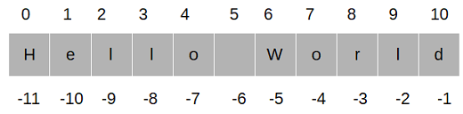

Reverse Column Selection with iloc

```python
reading_csv_files_example.iloc[77:81,-3:]
```

|  | city-mpg | highway-mpg | price |
| --- | --- | --- | --- |
| 77 | 23 | 30 | 9959 |
| 78 | 25 | 32 | 8499 |
| 79 | 19 | 24 | 12629 |
| 80 | 19 | 24 | 14869 |

The Second Example for Reverse Column Selection with iloc

```python
reading_csv_files_example.iloc[-2:,-2:]
```

|  | highway-mpg | price |
| --- | --- | --- |
| 199 | 27 | 22470 |
| 200 | 25 | 22625 |

In this second example, we have selected the last two columns and rows in the DataFrame. If I need to draw an analogy, we selected the right bottom edge of the DataFrame.

The Third Example with iloc

```python
reading_csv_files_example.iloc[-44:-40,-5:-2]
```

|  | horsepower | peak-rpm | city-mpg |
| --- | --- | --- | --- |
| 157 | 70.0 | 4800.0 | 28 |
| 158 | 70.0 | 4800.0 | 28 |
| 159 | 70.0 | 4800.0 | 29 |
| 160 | 70.0 | 4800.0 | 29 |

#### 3.5.2 - Label-based Selection with loc function

Access a group of rows and columns by label(s) or a boolean array. .loc[] is primarily label based, but may also be used with a boolean array. [Reference](https://pandas.pydata.org/docs/reference/api/pandas.DataFrame.loc.html)

```python
loc_function_example = pd.DataFrame({
    'Name':['Carlos','David','Emma','Chaplin','Gogol','Gabriel'],
     'City':['New York','London','Berlin','Tokyo','Moscow','Aracataca'],
      'Sex':['Male','Male','Female','Male','Male','Male']},
       index = ['The first row','the 2nd Row',3,'okay','The Overcoat','One Hundred Years of solitude']
                                            )

loc_function_example
```

|  | Name | City | Sex |
| --- | --- | --- | --- |
| The first row | Carlos | New York | Male |
| the 2nd Row | David | London | Male |
| 3 | Emma | Berlin | Female |
| okay | Chaplin | Tokyo | Male |
| The Overcoat | Gogol | Moscow | Male |
| One Hundred Years of solitude | Gabriel | Aracataca | Male |

The Row Selection with loc

```python
loc_function_example.loc[[3,'okay','The Overcoat']]
```

|  | Name | City | Sex |
| --- | --- | --- | --- |
| 3 | Emma | Berlin | Female |
| okay | Chaplin | Tokyo | Male |
| The Overcoat | Gogol | Moscow | Male |

In this above example, when we apply the loc function in Pandas, we need to write the exact column name inside quotes down, othervise we fail to get the DataFrame. On the other hand, as you can see that, we are able to get the column name in order to in code block.

The Column Selection

```python
loc_function_example.loc[:,['Name']]
```

|  | Name |
| --- | --- |
| The first row | Carlos |
| the 2nd Row | David |
| 3 | Emma |
| okay | Chaplin |
| The Overcoat | Gogol |
| One Hundred Years of solitude | Gabriel |

```python
loc_function_example.loc[:,['Name','Sex']]
```

|  | Name | Sex |
| --- | --- | --- |
| The first row | Carlos | Male |
| the 2nd Row | David | Male |
| 3 | Emma | Female |
| okay | Chaplin | Male |
| The Overcoat | Gogol | Male |
| One Hundred Years of solitude | Gabriel | Male |

The Row and Column Selection

```python
loc_function_example.loc[['One Hundred Years of solitude'],['Name','City']]
```

|  | Name | City |
| --- | --- | --- |
| One Hundred Years of solitude | Gabriel | Aracataca |

Conditional Selection

```python
reading_csv_files_example.head()
```

|  | symboling | normalized-losses | make | fuel-type | aspiration | num-of-doors | body-style | drive-wheels | engine-location | wheel-base | ... | engine-size | fuel-system | bore | stroke | compression-ratio | horsepower | peak-rpm | city-mpg | highway-mpg | price |
| --- | --- | --- | --- | --- | --- | --- | --- | --- | --- | --- | --- | --- | --- | --- | --- | --- | --- | --- | --- | --- | --- |
| 0 | 3 | 122.0 | alfa-romero | gas | std | two | convertible | rwd | front | 88.6 | ... | 130 | mpfi | 3.47 | 2.68 | 9.0 | 111.0 | 5000.0 | 21 | 27 | 13495 |
| 1 | 3 | 122.0 | alfa-romero | gas | std | two | convertible | rwd | front | 88.6 | ... | 130 | mpfi | 3.47 | 2.68 | 9.0 | 111.0 | 5000.0 | 21 | 27 | 16500 |
| 2 | 1 | 122.0 | alfa-romero | gas | std | two | hatchback | rwd | front | 94.5 | ... | 152 | mpfi | 2.68 | 3.47 | 9.0 | 154.0 | 5000.0 | 19 | 26 | 16500 |
| 3 | 2 | 164.0 | audi | gas | std | four | sedan | fwd | front | 99.8 | ... | 109 | mpfi | 3.19 | 3.40 | 10.0 | 102.0 | 5500.0 | 24 | 30 | 13950 |
| 4 | 2 | 164.0 | audi | gas | std | four | sedan | 4wd | front | 99.4 | ... | 136 | mpfi | 3.19 | 3.40 | 8.0 | 115.0 | 5500.0 | 18 | 22 | 17450 |

5 rows × 26 columns

The First Example

```python
reading_csv_files_example[reading_csv_files_example['horsepower'] == 111]
```

|  | symboling | normalized-losses | make | fuel-type | aspiration | num-of-doors | body-style | drive-wheels | engine-location | wheel-base | ... | engine-size | fuel-system | bore | stroke | compression-ratio | horsepower | peak-rpm | city-mpg | highway-mpg | price |
| --- | --- | --- | --- | --- | --- | --- | --- | --- | --- | --- | --- | --- | --- | --- | --- | --- | --- | --- | --- | --- | --- |
| 0 | 3 | 122.0 | alfa-romero | gas | std | two | convertible | rwd | front | 88.6 | ... | 130 | mpfi | 3.47 | 2.68 | 9.0 | 111.0 | 5000.0 | 21 | 27 | 13495 |
| 1 | 3 | 122.0 | alfa-romero | gas | std | two | convertible | rwd | front | 88.6 | ... | 130 | mpfi | 3.47 | 2.68 | 9.0 | 111.0 | 5000.0 | 21 | 27 | 16500 |
| 141 | 0 | 102.0 | subaru | gas | turbo | four | sedan | 4wd | front | 97.0 | ... | 108 | mpfi | 3.62 | 2.64 | 7.7 | 111.0 | 4800.0 | 24 | 29 | 11259 |
| 145 | 0 | 85.0 | subaru | gas | turbo | four | wagon | 4wd | front | 96.9 | ... | 108 | mpfi | 3.62 | 2.64 | 7.7 | 111.0 | 4800.0 | 23 | 23 | 11694 |

4 rows × 26 columns

The Second Example

```python
reading_csv_files_example[

        (reading_csv_files_example.bore == 3.47) &
        (reading_csv_files_example.price == 16500)

    ]
```

|  | symboling | normalized-losses | make | fuel-type | aspiration | num-of-doors | body-style | drive-wheels | engine-location | wheel-base | ... | engine-size | fuel-system | bore | stroke | compression-ratio | horsepower | peak-rpm | city-mpg | highway-mpg | price |
| --- | --- | --- | --- | --- | --- | --- | --- | --- | --- | --- | --- | --- | --- | --- | --- | --- | --- | --- | --- | --- | --- |
| 1 | 3 | 122.0 | alfa-romero | gas | std | two | convertible | rwd | front | 88.6 | ... | 130 | mpfi | 3.47 | 2.68 | 9.0 | 111.0 | 5000.0 | 21 | 27 | 16500 |

1 rows × 26 columns

Multiple Conditional Selection

```python
reading_csv_files_example[
    (reading_csv_files_example['normalized-losses'] > 170) &
    ((reading_csv_files_example['wheel-base'] > 90) & (reading_csv_files_example['wheel-base'] < 100) &
    ((reading_csv_files_example.stroke > 3.11) | (reading_csv_files_example.stroke<= 3.40)))
]
```

|  | symboling | normalized-losses | make | fuel-type | aspiration | num-of-doors | body-style | drive-wheels | engine-location | wheel-base | ... | engine-size | fuel-system | bore | stroke | compression-ratio | horsepower | peak-rpm | city-mpg | highway-mpg | price |
| --- | --- | --- | --- | --- | --- | --- | --- | --- | --- | --- | --- | --- | --- | --- | --- | --- | --- | --- | --- | --- | --- |
| 101 | 3 | 194.0 | nissan | gas | std | two | hatchback | rwd | front | 91.3 | ... | 181 | mpfi | 3.43 | 3.27 | 9.0 | 160.0 | 5200.0 | 19 | 25 | 17199 |
| 102 | 3 | 194.0 | nissan | gas | turbo | two | hatchback | rwd | front | 91.3 | ... | 181 | mpfi | 3.43 | 3.27 | 7.8 | 200.0 | 5200.0 | 17 | 23 | 19699 |
| 103 | 1 | 231.0 | nissan | gas | std | two | hatchback | rwd | front | 99.2 | ... | 181 | mpfi | 3.43 | 3.27 | 9.0 | 160.0 | 5200.0 | 19 | 25 | 18399 |
| 122 | 3 | 186.0 | porsche | gas | std | two | hatchback | rwd | front | 94.5 | ... | 151 | mpfi | 3.94 | 3.11 | 9.5 | 143.0 | 5500.0 | 19 | 27 | 22018 |
| 186 | 3 | 256.0 | volkswagen | gas | std | two | hatchback | fwd | front | 94.5 | ... | 109 | mpfi | 3.19 | 3.40 | 8.5 | 90.0 | 5500.0 | 24 | 29 | 9980 |

5 rows × 26 columns

Multiple Conditional Selection - 2

```python
reading_csv_files_example[
    ((reading_csv_files_example['aspiration'] == 'std') & (reading_csv_files_example['body-style'] == 'convertible')) |
    ((reading_csv_files_example['drive-wheels'] == 'rwd') & (reading_csv_files_example['fuel-system'] == 'spdi'))]
```

|  | symboling | normalized-losses | make | fuel-type | aspiration | num-of-doors | body-style | drive-wheels | engine-location | wheel-base | ... | engine-size | fuel-system | bore | stroke | compression-ratio | horsepower | peak-rpm | city-mpg | highway-mpg | price |
| --- | --- | --- | --- | --- | --- | --- | --- | --- | --- | --- | --- | --- | --- | --- | --- | --- | --- | --- | --- | --- | --- |
| 0 | 3 | 122.0 | alfa-romero | gas | std | two | convertible | rwd | front | 88.6 | ... | 130 | mpfi | 3.47 | 2.68 | 9.0 | 111.0 | 5000.0 | 21 | 27 | 13495 |
| 1 | 3 | 122.0 | alfa-romero | gas | std | two | convertible | rwd | front | 88.6 | ... | 130 | mpfi | 3.47 | 2.68 | 9.0 | 111.0 | 5000.0 | 21 | 27 | 16500 |
| 69 | 3 | 142.0 | mercedes-benz | gas | std | two | convertible | rwd | front | 96.6 | ... | 234 | mpfi | 3.46 | 3.10 | 8.3 | 155.0 | 4750.0 | 16 | 18 | 35056 |
| 121 | 3 | 122.0 | plymouth | gas | turbo | two | hatchback | rwd | front | 95.9 | ... | 156 | spdi | 3.59 | 3.86 | 7.0 | 145.0 | 5000.0 | 19 | 24 | 12764 |
| 125 | 3 | 122.0 | porsche | gas | std | two | convertible | rwd | rear | 89.5 | ... | 194 | mpfi | 3.74 | 2.90 | 9.5 | 207.0 | 5900.0 | 17 | 25 | 37028 |
| 168 | 2 | 134.0 | toyota | gas | std | two | convertible | rwd | front | 98.4 | ... | 146 | mpfi | 3.62 | 3.50 | 9.3 | 116.0 | 4800.0 | 24 | 30 | 17669 |
| 185 | 3 | 122.0 | volkswagen | gas | std | two | convertible | fwd | front | 94.5 | ... | 109 | mpfi | 3.19 | 3.40 | 8.5 | 90.0 | 5500.0 | 24 | 29 | 11595 |

7 rows × 26 columns

isin function

isin is used to filter data frames. isin() method helps in selecting rows with having a particular(or Multiple) value in a particular column. [Reference](https://www.geeksforgeeks.org/python-pandas-dataframe-isin/)

```python
isin_function_example = pd.DataFrame({'Legs': [2, 4,2], 'Wings': [2, 0,2]},
                  index=['Eagle', 'Dog','Ostrich'])
isin_function_example
```

|  | Legs | Wings |
| --- | --- | --- |
| Eagle | 2 | 2 |
| Dog | 4 | 0 |
| Ostrich | 2 | 2 |

```python
isin_function_example.isin([1])
```

|  | Legs | Wings |
| --- | --- | --- |
| Eagle | False | False |
| Dog | False | False |
| Ostrich | False | False |

```python
isin_function_example.isin([1,2,3])
```

|  | Legs | Wings |
| --- | --- | --- |
| Eagle | True | True |
| Dog | False | False |
| Ostrich | True | True |

```python
isin_function_example.isin({'Wings':[0,3,5]})
```

|  | Legs | Wings |
| --- | --- | --- |
| Eagle | False | False |
| Dog | False | True |
| Ostrich | False | False |

```python
isin_function_example.isin({'Wings':[1],'Legs':[4,2]})
```

|  | Legs | Wings |
| --- | --- | --- |
| Eagle | True | False |
| Dog | True | False |
| Ostrich | True | False |

```python
isin_function_example2 = reading_csv_files_example["make"].isin(['isuzu'])

reading_csv_files_example[isin_function_example2]
```

|  | symboling | normalized-losses | make | fuel-type | aspiration | num-of-doors | body-style | drive-wheels | engine-location | wheel-base | ... | engine-size | fuel-system | bore | stroke | compression-ratio | horsepower | peak-rpm | city-mpg | highway-mpg | price |
| --- | --- | --- | --- | --- | --- | --- | --- | --- | --- | --- | --- | --- | --- | --- | --- | --- | --- | --- | --- | --- | --- |
| 42 | 0 | 122.0 | isuzu | gas | std | four | sedan | rwd | front | 94.3 | ... | 111 | 2bbl | 3.31 | 3.23 | 8.5 | 78.0 | 4800.0 | 24 | 29 | 6785 |
| 43 | 2 | 122.0 | isuzu | gas | std | two | hatchback | rwd | front | 96.0 | ... | 119 | spfi | 3.43 | 3.23 | 9.2 | 90.0 | 5000.0 | 24 | 29 | 11048 |

2 rows × 26 columns

In above example, we have selected " isuzu ", which is being in the row of " make ".

```python
isin_function_example3 = reading_csv_files_example["make"].isin(['renault','saab'])

reading_csv_files_example[isin_function_example3]
```

|  | symboling | normalized-losses | make | fuel-type | aspiration | num-of-doors | body-style | drive-wheels | engine-location | wheel-base | ... | engine-size | fuel-system | bore | stroke | compression-ratio | horsepower | peak-rpm | city-mpg | highway-mpg | price |
| --- | --- | --- | --- | --- | --- | --- | --- | --- | --- | --- | --- | --- | --- | --- | --- | --- | --- | --- | --- | --- | --- |
| 126 | 0 | 122.0 | renault | gas | std | four | wagon | fwd | front | 96.1 | ... | 132 | mpfi | 3.46 | 3.90 | 8.70 | 104.256158 | 5125.369458 | 23 | 31 | 9295 |
| 127 | 2 | 122.0 | renault | gas | std | two | hatchback | fwd | front | 96.1 | ... | 132 | mpfi | 3.46 | 3.90 | 8.70 | 104.256158 | 5125.369458 | 23 | 31 | 9895 |
| 128 | 3 | 150.0 | saab | gas | std | two | hatchback | fwd | front | 99.1 | ... | 121 | mpfi | 3.54 | 3.07 | 9.31 | 110.000000 | 5250.000000 | 21 | 28 | 11850 |
| 129 | 2 | 104.0 | saab | gas | std | four | sedan | fwd | front | 99.1 | ... | 121 | mpfi | 3.54 | 3.07 | 9.30 | 110.000000 | 5250.000000 | 21 | 28 | 12170 |
| 130 | 3 | 150.0 | saab | gas | std | two | hatchback | fwd | front | 99.1 | ... | 121 | mpfi | 2.54 | 2.07 | 9.30 | 110.000000 | 5250.000000 | 21 | 28 | 15040 |
| 131 | 2 | 104.0 | saab | gas | std | four | sedan | fwd | front | 99.1 | ... | 121 | mpfi | 3.54 | 3.07 | 9.30 | 110.000000 | 5250.000000 | 21 | 28 | 15510 |
| 132 | 3 | 150.0 | saab | gas | turbo | two | hatchback | fwd | front | 99.1 | ... | 121 | mpfi | 3.54 | 3.07 | 9.00 | 160.000000 | 5500.000000 | 19 | 26 | 18150 |
| 133 | 2 | 104.0 | saab | gas | turbo | four | sedan | fwd | front | 99.1 | ... | 121 | mpfi | 3.54 | 3.07 | 9.00 | 160.000000 | 5500.000000 | 19 | 26 | 18620 |

8 rows × 26 columns

In above example, we have selected " renault " and " saab " , which is being in the row of " make ".

Str Accessor

Pandas is a highly efficient library on textual data as well. The functions and methods under the str accessor provide flexible ways to filter rows based on strings. For instance, we can select the names that starts with the words “do” in below example.

```python
reading_csv_files_example[reading_csv_files_example['make'].str.startswith('do')]
```

|  | symboling | normalized-losses | make | fuel-type | aspiration | num-of-doors | body-style | drive-wheels | engine-location | wheel-base | ... | engine-size | fuel-system | bore | stroke | compression-ratio | horsepower | peak-rpm | city-mpg | highway-mpg | price |
| --- | --- | --- | --- | --- | --- | --- | --- | --- | --- | --- | --- | --- | --- | --- | --- | --- | --- | --- | --- | --- | --- |
| 20 | 1 | 118.0 | dodge | gas | std | two | hatchback | fwd | front | 93.7 | ... | 90 | 2bbl | 2.97 | 3.23 | 9.41 | 68.0 | 5500.0 | 37 | 41 | 5572 |
| 21 | 1 | 118.0 | dodge | gas | std | two | hatchback | fwd | front | 93.7 | ... | 90 | 2bbl | 2.97 | 3.23 | 9.40 | 68.0 | 5500.0 | 31 | 38 | 6377 |
| 22 | 1 | 118.0 | dodge | gas | turbo | two | hatchback | fwd | front | 93.7 | ... | 98 | mpfi | 3.03 | 3.39 | 7.60 | 102.0 | 5500.0 | 24 | 30 | 7957 |
| 23 | 1 | 148.0 | dodge | gas | std | four | hatchback | fwd | front | 93.7 | ... | 90 | 2bbl | 2.97 | 3.23 | 9.40 | 68.0 | 5500.0 | 31 | 38 | 6229 |
| 24 | 1 | 148.0 | dodge | gas | std | four | sedan | fwd | front | 93.7 | ... | 90 | 2bbl | 2.97 | 3.23 | 9.40 | 68.0 | 5500.0 | 31 | 38 | 6692 |
| 25 | 1 | 148.0 | dodge | gas | std | four | sedan | fwd | front | 93.7 | ... | 90 | 2bbl | 2.97 | 3.23 | 9.40 | 68.0 | 5500.0 | 31 | 38 | 7609 |
| 26 | 1 | 148.0 | dodge | gas | turbo | four | sedan | fwd | front | 93.7 | ... | 98 | mpfi | 3.03 | 3.39 | 7.60 | 102.0 | 5500.0 | 24 | 30 | 8558 |
| 27 | -1 | 110.0 | dodge | gas | std | four | wagon | fwd | front | 103.3 | ... | 122 | 2bbl | 3.34 | 3.46 | 8.50 | 88.0 | 5000.0 | 24 | 30 | 8921 |
| 28 | 3 | 145.0 | dodge | gas | turbo | two | hatchback | fwd | front | 95.9 | ... | 156 | mfi | 3.60 | 3.90 | 7.00 | 145.0 | 5000.0 | 19 | 24 | 12964 |

9 rows × 26 columns

In above example, we have filtered the cars starting with two letters, like " do ", in make column.

```python
reading_csv_files_example[reading_csv_files_example['make'].str.endswith('ge')]
```

|  | symboling | normalized-losses | make | fuel-type | aspiration | num-of-doors | body-style | drive-wheels | engine-location | wheel-base | ... | engine-size | fuel-system | bore | stroke | compression-ratio | horsepower | peak-rpm | city-mpg | highway-mpg | price |
| --- | --- | --- | --- | --- | --- | --- | --- | --- | --- | --- | --- | --- | --- | --- | --- | --- | --- | --- | --- | --- | --- |
| 20 | 1 | 118.0 | dodge | gas | std | two | hatchback | fwd | front | 93.7 | ... | 90 | 2bbl | 2.97 | 3.23 | 9.41 | 68.0 | 5500.0 | 37 | 41 | 5572 |
| 21 | 1 | 118.0 | dodge | gas | std | two | hatchback | fwd | front | 93.7 | ... | 90 | 2bbl | 2.97 | 3.23 | 9.40 | 68.0 | 5500.0 | 31 | 38 | 6377 |
| 22 | 1 | 118.0 | dodge | gas | turbo | two | hatchback | fwd | front | 93.7 | ... | 98 | mpfi | 3.03 | 3.39 | 7.60 | 102.0 | 5500.0 | 24 | 30 | 7957 |
| 23 | 1 | 148.0 | dodge | gas | std | four | hatchback | fwd | front | 93.7 | ... | 90 | 2bbl | 2.97 | 3.23 | 9.40 | 68.0 | 5500.0 | 31 | 38 | 6229 |
| 24 | 1 | 148.0 | dodge | gas | std | four | sedan | fwd | front | 93.7 | ... | 90 | 2bbl | 2.97 | 3.23 | 9.40 | 68.0 | 5500.0 | 31 | 38 | 6692 |
| 25 | 1 | 148.0 | dodge | gas | std | four | sedan | fwd | front | 93.7 | ... | 90 | 2bbl | 2.97 | 3.23 | 9.40 | 68.0 | 5500.0 | 31 | 38 | 7609 |
| 26 | 1 | 148.0 | dodge | gas | turbo | four | sedan | fwd | front | 93.7 | ... | 98 | mpfi | 3.03 | 3.39 | 7.60 | 102.0 | 5500.0 | 24 | 30 | 8558 |
| 27 | -1 | 110.0 | dodge | gas | std | four | wagon | fwd | front | 103.3 | ... | 122 | 2bbl | 3.34 | 3.46 | 8.50 | 88.0 | 5000.0 | 24 | 30 | 8921 |
| 28 | 3 | 145.0 | dodge | gas | turbo | two | hatchback | fwd | front | 95.9 | ... | 156 | mfi | 3.60 | 3.90 | 7.00 | 145.0 | 5000.0 | 19 | 24 | 12964 |

9 rows × 26 columns

In above example, we have selected the cars, ending with " ge " in make column by using " endswith() ".

```python
reading_csv_files_example[reading_csv_files_example['body-style'].str.startswith('c')]
```

|  | symboling | normalized-losses | make | fuel-type | aspiration | num-of-doors | body-style | drive-wheels | engine-location | wheel-base | ... | engine-size | fuel-system | bore | stroke | compression-ratio | horsepower | peak-rpm | city-mpg | highway-mpg | price |
| --- | --- | --- | --- | --- | --- | --- | --- | --- | --- | --- | --- | --- | --- | --- | --- | --- | --- | --- | --- | --- | --- |
| 0 | 3 | 122.0 | alfa-romero | gas | std | two | convertible | rwd | front | 88.6 | ... | 130 | mpfi | 3.47 | 2.68 | 9.0 | 111.0 | 5000.0 | 21 | 27 | 13495 |
| 1 | 3 | 122.0 | alfa-romero | gas | std | two | convertible | rwd | front | 88.6 | ... | 130 | mpfi | 3.47 | 2.68 | 9.0 | 111.0 | 5000.0 | 21 | 27 | 16500 |
| 69 | 3 | 142.0 | mercedes-benz | gas | std | two | convertible | rwd | front | 96.6 | ... | 234 | mpfi | 3.46 | 3.10 | 8.3 | 155.0 | 4750.0 | 16 | 18 | 35056 |
| 125 | 3 | 122.0 | porsche | gas | std | two | convertible | rwd | rear | 89.5 | ... | 194 | mpfi | 3.74 | 2.90 | 9.5 | 207.0 | 5900.0 | 17 | 25 | 37028 |
| 168 | 2 | 134.0 | toyota | gas | std | two | convertible | rwd | front | 98.4 | ... | 146 | mpfi | 3.62 | 3.50 | 9.3 | 116.0 | 4800.0 | 24 | 30 | 17669 |
| 185 | 3 | 122.0 | volkswagen | gas | std | two | convertible | fwd | front | 94.5 | ... | 109 | mpfi | 3.19 | 3.40 | 8.5 | 90.0 | 5500.0 | 24 | 29 | 11595 |

6 rows × 26 columns

```python
reading_csv_files_example[reading_csv_files_example['make'].str.endswith('u')]
```

|  | symboling | normalized-losses | make | fuel-type | aspiration | num-of-doors | body-style | drive-wheels | engine-location | wheel-base | ... | engine-size | fuel-system | bore | stroke | compression-ratio | horsepower | peak-rpm | city-mpg | highway-mpg | price |
| --- | --- | --- | --- | --- | --- | --- | --- | --- | --- | --- | --- | --- | --- | --- | --- | --- | --- | --- | --- | --- | --- |
| 42 | 0 | 122.0 | isuzu | gas | std | four | sedan | rwd | front | 94.3 | ... | 111 | 2bbl | 3.31 | 3.23 | 8.5 | 78.0 | 4800.0 | 24 | 29 | 6785 |
| 43 | 2 | 122.0 | isuzu | gas | std | two | hatchback | rwd | front | 96.0 | ... | 119 | spfi | 3.43 | 3.23 | 9.2 | 90.0 | 5000.0 | 24 | 29 | 11048 |
| 134 | 2 | 83.0 | subaru | gas | std | two | hatchback | fwd | front | 93.7 | ... | 97 | 2bbl | 3.62 | 2.36 | 9.0 | 69.0 | 4900.0 | 31 | 36 | 5118 |
| 135 | 2 | 83.0 | subaru | gas | std | two | hatchback | fwd | front | 93.7 | ... | 108 | 2bbl | 3.62 | 2.64 | 8.7 | 73.0 | 4400.0 | 26 | 31 | 7053 |
| 136 | 2 | 83.0 | subaru | gas | std | two | hatchback | 4wd | front | 93.3 | ... | 108 | 2bbl | 3.62 | 2.64 | 8.7 | 73.0 | 4400.0 | 26 | 31 | 7603 |
| 137 | 0 | 102.0 | subaru | gas | std | four | sedan | fwd | front | 97.2 | ... | 108 | 2bbl | 3.62 | 2.64 | 9.5 | 82.0 | 4800.0 | 32 | 37 | 7126 |
| 138 | 0 | 102.0 | subaru | gas | std | four | sedan | fwd | front | 97.2 | ... | 108 | 2bbl | 3.62 | 2.64 | 9.5 | 82.0 | 4400.0 | 28 | 33 | 7775 |
| 139 | 0 | 102.0 | subaru | gas | std | four | sedan | fwd | front | 97.2 | ... | 108 | mpfi | 3.62 | 2.64 | 9.0 | 94.0 | 5200.0 | 26 | 32 | 9960 |
| 140 | 0 | 102.0 | subaru | gas | std | four | sedan | 4wd | front | 97.0 | ... | 108 | 2bbl | 3.62 | 2.64 | 9.0 | 82.0 | 4800.0 | 24 | 25 | 9233 |
| 141 | 0 | 102.0 | subaru | gas | turbo | four | sedan | 4wd | front | 97.0 | ... | 108 | mpfi | 3.62 | 2.64 | 7.7 | 111.0 | 4800.0 | 24 | 29 | 11259 |
| 142 | 0 | 89.0 | subaru | gas | std | four | wagon | fwd | front | 97.0 | ... | 108 | 2bbl | 3.62 | 2.64 | 9.0 | 82.0 | 4800.0 | 28 | 32 | 7463 |
| 143 | 0 | 89.0 | subaru | gas | std | four | wagon | fwd | front | 97.0 | ... | 108 | mpfi | 3.62 | 2.64 | 9.0 | 94.0 | 5200.0 | 25 | 31 | 10198 |
| 144 | 0 | 85.0 | subaru | gas | std | four | wagon | 4wd | front | 96.9 | ... | 108 | 2bbl | 3.62 | 2.64 | 9.0 | 82.0 | 4800.0 | 23 | 29 | 8013 |
| 145 | 0 | 85.0 | subaru | gas | turbo | four | wagon | 4wd | front | 96.9 | ... | 108 | mpfi | 3.62 | 2.64 | 7.7 | 111.0 | 4800.0 | 23 | 23 | 11694 |

14 rows × 26 columns

```python
reading_csv_files_example[reading_csv_files_example['engine-location'].str.startswith('r')]
```

|  | symboling | normalized-losses | make | fuel-type | aspiration | num-of-doors | body-style | drive-wheels | engine-location | wheel-base | ... | engine-size | fuel-system | bore | stroke | compression-ratio | horsepower | peak-rpm | city-mpg | highway-mpg | price |
| --- | --- | --- | --- | --- | --- | --- | --- | --- | --- | --- | --- | --- | --- | --- | --- | --- | --- | --- | --- | --- | --- |
| 123 | 3 | 122.0 | porsche | gas | std | two | hardtop | rwd | rear | 89.5 | ... | 194 | mpfi | 3.74 | 2.9 | 9.5 | 207.0 | 5900.0 | 17 | 25 | 32528 |
| 124 | 3 | 122.0 | porsche | gas | std | two | hardtop | rwd | rear | 89.5 | ... | 194 | mpfi | 3.74 | 2.9 | 9.5 | 207.0 | 5900.0 | 17 | 25 | 34028 |
| 125 | 3 | 122.0 | porsche | gas | std | two | convertible | rwd | rear | 89.5 | ... | 194 | mpfi | 3.74 | 2.9 | 9.5 | 207.0 | 5900.0 | 17 | 25 | 37028 |

3 rows × 26 columns

```python
reading_csv_files_example[reading_csv_files_example['body-style'].str.startswith('c')]
```

|  | symboling | normalized-losses | make | fuel-type | aspiration | num-of-doors | body-style | drive-wheels | engine-location | wheel-base | ... | engine-size | fuel-system | bore | stroke | compression-ratio | horsepower | peak-rpm | city-mpg | highway-mpg | price |
| --- | --- | --- | --- | --- | --- | --- | --- | --- | --- | --- | --- | --- | --- | --- | --- | --- | --- | --- | --- | --- | --- |
| 0 | 3 | 122.0 | alfa-romero | gas | std | two | convertible | rwd | front | 88.6 | ... | 130 | mpfi | 3.47 | 2.68 | 9.0 | 111.0 | 5000.0 | 21 | 27 | 13495 |
| 1 | 3 | 122.0 | alfa-romero | gas | std | two | convertible | rwd | front | 88.6 | ... | 130 | mpfi | 3.47 | 2.68 | 9.0 | 111.0 | 5000.0 | 21 | 27 | 16500 |
| 69 | 3 | 142.0 | mercedes-benz | gas | std | two | convertible | rwd | front | 96.6 | ... | 234 | mpfi | 3.46 | 3.10 | 8.3 | 155.0 | 4750.0 | 16 | 18 | 35056 |
| 125 | 3 | 122.0 | porsche | gas | std | two | convertible | rwd | rear | 89.5 | ... | 194 | mpfi | 3.74 | 2.90 | 9.5 | 207.0 | 5900.0 | 17 | 25 | 37028 |
| 168 | 2 | 134.0 | toyota | gas | std | two | convertible | rwd | front | 98.4 | ... | 146 | mpfi | 3.62 | 3.50 | 9.3 | 116.0 | 4800.0 | 24 | 30 | 17669 |
| 185 | 3 | 122.0 | volkswagen | gas | std | two | convertible | fwd | front | 94.5 | ... | 109 | mpfi | 3.19 | 3.40 | 8.5 | 90.0 | 5500.0 | 24 | 29 | 11595 |

6 rows × 26 columns

Query

The query() method allows you to query the DataFrame and takes a query expression as a string parameter, which has to evaluate to either True of False. [Reference](https://www.w3schools.com/python/pandas/ref_df_query.asp) The query function offers a little more flexibility at writing the conditions for filtering. We can pass the conditions as a string.

The below example is a basic example for query method.

```python
reading_csv_files_example.query('horsepower > 200')
```

|  | symboling | normalized-losses | make | fuel-type | aspiration | num-of-doors | body-style | drive-wheels | engine-location | wheel-base | ... | engine-size | fuel-system | bore | stroke | compression-ratio | horsepower | peak-rpm | city-mpg | highway-mpg | price |
| --- | --- | --- | --- | --- | --- | --- | --- | --- | --- | --- | --- | --- | --- | --- | --- | --- | --- | --- | --- | --- | --- |
| 46 | 0 | 122.0 | jaguar | gas | std | two | sedan | rwd | front | 102.0 | ... | 326 | mpfi | 3.54 | 2.76 | 11.5 | 262.0 | 5000.0 | 13 | 17 | 36000 |
| 123 | 3 | 122.0 | porsche | gas | std | two | hardtop | rwd | rear | 89.5 | ... | 194 | mpfi | 3.74 | 2.90 | 9.5 | 207.0 | 5900.0 | 17 | 25 | 32528 |
| 124 | 3 | 122.0 | porsche | gas | std | two | hardtop | rwd | rear | 89.5 | ... | 194 | mpfi | 3.74 | 2.90 | 9.5 | 207.0 | 5900.0 | 17 | 25 | 34028 |
| 125 | 3 | 122.0 | porsche | gas | std | two | convertible | rwd | rear | 89.5 | ... | 194 | mpfi | 3.74 | 2.90 | 9.5 | 207.0 | 5900.0 | 17 | 25 | 37028 |

4 rows × 26 columns

In the second example, we are going to learn how to apply " Multiple Condtion Filtering " .

```python
reading_csv_files_example.query('stroke > 3.5 and price < 15000 and aspiration == "turbo" ')
```

|  | symboling | normalized-losses | make | fuel-type | aspiration | num-of-doors | body-style | drive-wheels | engine-location | wheel-base | ... | engine-size | fuel-system | bore | stroke | compression-ratio | horsepower | peak-rpm | city-mpg | highway-mpg | price |
| --- | --- | --- | --- | --- | --- | --- | --- | --- | --- | --- | --- | --- | --- | --- | --- | --- | --- | --- | --- | --- | --- |
| 28 | 3 | 145.0 | dodge | gas | turbo | two | hatchback | fwd | front | 95.9 | ... | 156 | mfi | 3.60 | 3.90 | 7.0 | 145.0 | 5000.0 | 19 | 24 | 12964 |
| 79 | 3 | 122.0 | mitsubishi | gas | turbo | two | hatchback | fwd | front | 95.9 | ... | 156 | spdi | 3.58 | 3.86 | 7.0 | 145.0 | 5000.0 | 19 | 24 | 12629 |
| 80 | 3 | 122.0 | mitsubishi | gas | turbo | two | hatchback | fwd | front | 95.9 | ... | 156 | spdi | 3.59 | 3.86 | 7.0 | 145.0 | 5000.0 | 19 | 24 | 14869 |
| 81 | 3 | 122.0 | mitsubishi | gas | turbo | two | hatchback | fwd | front | 95.9 | ... | 156 | spdi | 3.59 | 3.86 | 7.0 | 145.0 | 5000.0 | 19 | 24 | 14489 |
| 105 | 0 | 161.0 | peugot | diesel | turbo | four | sedan | rwd | front | 107.9 | ... | 152 | idi | 3.70 | 3.52 | 21.0 | 95.0 | 4150.0 | 28 | 33 | 13200 |
| 107 | 0 | 122.0 | peugot | diesel | turbo | four | wagon | rwd | front | 114.2 | ... | 152 | idi | 3.70 | 3.52 | 21.0 | 95.0 | 4150.0 | 25 | 25 | 13860 |
| 121 | 3 | 122.0 | plymouth | gas | turbo | two | hatchback | rwd | front | 95.9 | ... | 156 | spdi | 3.59 | 3.86 | 7.0 | 145.0 | 5000.0 | 19 | 24 | 12764 |

7 rows × 26 columns

In the third example, we are going to combine the filtering with using query method and filtering without using query method.

Combining the filtering with using query method

```python
reading_csv_files_example.query('bore == stroke')
```

|  | symboling | normalized-losses | make | fuel-type | aspiration | num-of-doors | body-style | drive-wheels | engine-location | wheel-base | ... | engine-size | fuel-system | bore | stroke | compression-ratio | horsepower | peak-rpm | city-mpg | highway-mpg | price |
| --- | --- | --- | --- | --- | --- | --- | --- | --- | --- | --- | --- | --- | --- | --- | --- | --- | --- | --- | --- | --- | --- |
| 56 | 1 | 129.0 | mazda | gas | std | two | hatchback | fwd | front | 98.8 | ... | 122 | 2bbl | 3.39 | 3.39 | 8.6 | 84.0 | 4800.0 | 26 | 32 | 8845 |
| 57 | 0 | 115.0 | mazda | gas | std | four | sedan | fwd | front | 98.8 | ... | 122 | 2bbl | 3.39 | 3.39 | 8.6 | 84.0 | 4800.0 | 26 | 32 | 8495 |
| 58 | 1 | 129.0 | mazda | gas | std | two | hatchback | fwd | front | 98.8 | ... | 122 | 2bbl | 3.39 | 3.39 | 8.6 | 84.0 | 4800.0 | 26 | 32 | 10595 |
| 59 | 0 | 115.0 | mazda | gas | std | four | sedan | fwd | front | 98.8 | ... | 122 | 2bbl | 3.39 | 3.39 | 8.6 | 84.0 | 4800.0 | 26 | 32 | 10245 |
| 60 | 0 | 122.0 | mazda | diesel | std | four | sedan | fwd | front | 98.8 | ... | 122 | idi | 3.39 | 3.39 | 22.7 | 64.0 | 4650.0 | 36 | 42 | 10795 |
| 61 | 0 | 115.0 | mazda | gas | std | four | hatchback | fwd | front | 98.8 | ... | 122 | 2bbl | 3.39 | 3.39 | 8.6 | 84.0 | 4800.0 | 26 | 32 | 11245 |

6 rows × 26 columns

Combining the filtering without using query method

```python
reading_csv_files_example[reading_csv_files_example['bore'] == reading_csv_files_example['stroke']]
```

|  | symboling | normalized-losses | make | fuel-type | aspiration | num-of-doors | body-style | drive-wheels | engine-location | wheel-base | ... | engine-size | fuel-system | bore | stroke | compression-ratio | horsepower | peak-rpm | city-mpg | highway-mpg | price |
| --- | --- | --- | --- | --- | --- | --- | --- | --- | --- | --- | --- | --- | --- | --- | --- | --- | --- | --- | --- | --- | --- |
| 56 | 1 | 129.0 | mazda | gas | std | two | hatchback | fwd | front | 98.8 | ... | 122 | 2bbl | 3.39 | 3.39 | 8.6 | 84.0 | 4800.0 | 26 | 32 | 8845 |
| 57 | 0 | 115.0 | mazda | gas | std | four | sedan | fwd | front | 98.8 | ... | 122 | 2bbl | 3.39 | 3.39 | 8.6 | 84.0 | 4800.0 | 26 | 32 | 8495 |
| 58 | 1 | 129.0 | mazda | gas | std | two | hatchback | fwd | front | 98.8 | ... | 122 | 2bbl | 3.39 | 3.39 | 8.6 | 84.0 | 4800.0 | 26 | 32 | 10595 |
| 59 | 0 | 115.0 | mazda | gas | std | four | sedan | fwd | front | 98.8 | ... | 122 | 2bbl | 3.39 | 3.39 | 8.6 | 84.0 | 4800.0 | 26 | 32 | 10245 |
| 60 | 0 | 122.0 | mazda | diesel | std | four | sedan | fwd | front | 98.8 | ... | 122 | idi | 3.39 | 3.39 | 22.7 | 64.0 | 4650.0 | 36 | 42 | 10795 |
| 61 | 0 | 115.0 | mazda | gas | std | four | hatchback | fwd | front | 98.8 | ... | 122 | 2bbl | 3.39 | 3.39 | 8.6 | 84.0 | 4800.0 | 26 | 32 | 11245 |

6 rows × 26 columns

In the above last two examples, as we can see that, we good to filter DataFrame with both using or not using query method.

```python
reading_csv_files_example[
    (reading_csv_files_example['stroke'] > 3.5) &
    (reading_csv_files_example['price'] < 15000)&
    (reading_csv_files_example['aspiration'] == 'turbo')]
```

|  | symboling | normalized-losses | make | fuel-type | aspiration | num-of-doors | body-style | drive-wheels | engine-location | wheel-base | ... | engine-size | fuel-system | bore | stroke | compression-ratio | horsepower | peak-rpm | city-mpg | highway-mpg | price |
| --- | --- | --- | --- | --- | --- | --- | --- | --- | --- | --- | --- | --- | --- | --- | --- | --- | --- | --- | --- | --- | --- |
| 28 | 3 | 145.0 | dodge | gas | turbo | two | hatchback | fwd | front | 95.9 | ... | 156 | mfi | 3.60 | 3.90 | 7.0 | 145.0 | 5000.0 | 19 | 24 | 12964 |
| 79 | 3 | 122.0 | mitsubishi | gas | turbo | two | hatchback | fwd | front | 95.9 | ... | 156 | spdi | 3.58 | 3.86 | 7.0 | 145.0 | 5000.0 | 19 | 24 | 12629 |
| 80 | 3 | 122.0 | mitsubishi | gas | turbo | two | hatchback | fwd | front | 95.9 | ... | 156 | spdi | 3.59 | 3.86 | 7.0 | 145.0 | 5000.0 | 19 | 24 | 14869 |
| 81 | 3 | 122.0 | mitsubishi | gas | turbo | two | hatchback | fwd | front | 95.9 | ... | 156 | spdi | 3.59 | 3.86 | 7.0 | 145.0 | 5000.0 | 19 | 24 | 14489 |
| 105 | 0 | 161.0 | peugot | diesel | turbo | four | sedan | rwd | front | 107.9 | ... | 152 | idi | 3.70 | 3.52 | 21.0 | 95.0 | 4150.0 | 28 | 33 | 13200 |
| 107 | 0 | 122.0 | peugot | diesel | turbo | four | wagon | rwd | front | 114.2 | ... | 152 | idi | 3.70 | 3.52 | 21.0 | 95.0 | 4150.0 | 25 | 25 | 13860 |
| 121 | 3 | 122.0 | plymouth | gas | turbo | two | hatchback | rwd | front | 95.9 | ... | 156 | spdi | 3.59 | 3.86 | 7.0 | 145.0 | 5000.0 | 19 | 24 | 12764 |

7 rows × 26 columns

In the above last two examples, we have operate the Multiple Condition Filtering without using query method. NOTE: More knowledge and examples will be given in the next chapter.

Nlargest or nsmallest

In some cases, we do not have a specific range for filtering but just need the largest or smallest values. The nlargest and nsmallest functions allow for selecting rows that have the largest or smallest values in a column,respectively.

```python
reading_csv_files_example.nlargest(4, 'wheel-base')
```

|  | symboling | normalized-losses | make | fuel-type | aspiration | num-of-doors | body-style | drive-wheels | engine-location | wheel-base | ... | engine-size | fuel-system | bore | stroke | compression-ratio | horsepower | peak-rpm | city-mpg | highway-mpg | price |
| --- | --- | --- | --- | --- | --- | --- | --- | --- | --- | --- | --- | --- | --- | --- | --- | --- | --- | --- | --- | --- | --- |
| 70 | 0 | 122.0 | mercedes-benz | gas | std | four | sedan | rwd | front | 120.9 | ... | 308 | mpfi | 3.80 | 3.35 | 8.0 | 184.0 | 4500.0 | 14 | 16 | 40960 |
| 67 | -1 | 93.0 | mercedes-benz | diesel | turbo | four | sedan | rwd | front | 115.6 | ... | 183 | idi | 3.58 | 3.64 | 21.5 | 123.0 | 4350.0 | 22 | 25 | 31600 |
| 68 | -1 | 122.0 | mercedes-benz | gas | std | four | sedan | rwd | front | 115.6 | ... | 234 | mpfi | 3.46 | 3.10 | 8.3 | 155.0 | 4750.0 | 16 | 18 | 34184 |
| 106 | 0 | 122.0 | peugot | gas | std | four | wagon | rwd | front | 114.2 | ... | 120 | mpfi | 3.46 | 3.19 | 8.4 | 97.0 | 5000.0 | 19 | 24 | 12440 |

4 rows × 26 columns

```python
reading_csv_files_example.nsmallest(3, 'normalized-losses')
```

|  | symboling | normalized-losses | make | fuel-type | aspiration | num-of-doors | body-style | drive-wheels | engine-location | wheel-base | ... | engine-size | fuel-system | bore | stroke | compression-ratio | horsepower | peak-rpm | city-mpg | highway-mpg | price |
| --- | --- | --- | --- | --- | --- | --- | --- | --- | --- | --- | --- | --- | --- | --- | --- | --- | --- | --- | --- | --- | --- |
| 169 | -1 | 65.0 | toyota | gas | std | four | sedan | fwd | front | 102.4 | ... | 122 | mpfi | 3.31 | 3.54 | 8.7 | 92.0 | 4200.0 | 29 | 34 | 8948 |
| 170 | -1 | 65.0 | toyota | diesel | turbo | four | sedan | fwd | front | 102.4 | ... | 110 | idi | 3.27 | 3.35 | 22.5 | 73.0 | 4500.0 | 30 | 33 | 10698 |
| 171 | -1 | 65.0 | toyota | gas | std | four | hatchback | fwd | front | 102.4 | ... | 122 | mpfi | 3.31 | 3.54 | 8.7 | 92.0 | 4200.0 | 27 | 32 | 9988 |

3 rows × 26 columns

```python
reading_csv_files_example.nsmallest(7,'engine-size')
```

|  | symboling | normalized-losses | make | fuel-type | aspiration | num-of-doors | body-style | drive-wheels | engine-location | wheel-base | ... | engine-size | fuel-system | bore | stroke | compression-ratio | horsepower | peak-rpm | city-mpg | highway-mpg | price |
| --- | --- | --- | --- | --- | --- | --- | --- | --- | --- | --- | --- | --- | --- | --- | --- | --- | --- | --- | --- | --- | --- |
| 17 | 2 | 121.0 | chevrolet | gas | std | two | hatchback | fwd | front | 88.4 | ... | 61 | 2bbl | 2.910000 | 3.030000 | 9.5 | 48.0 | 5100.0 | 47 | 53 | 5151 |
| 52 | 3 | 150.0 | mazda | gas | std | two | hatchback | rwd | front | 95.3 | ... | 70 | 4bbl | 3.329751 | 3.255423 | 9.4 | 101.0 | 6000.0 | 17 | 23 | 10945 |
| 53 | 3 | 150.0 | mazda | gas | std | two | hatchback | rwd | front | 95.3 | ... | 70 | 4bbl | 3.329751 | 3.255423 | 9.4 | 101.0 | 6000.0 | 17 | 23 | 11845 |
| 54 | 3 | 150.0 | mazda | gas | std | two | hatchback | rwd | front | 95.3 | ... | 70 | 4bbl | 3.329751 | 3.255423 | 9.4 | 101.0 | 6000.0 | 17 | 23 | 13645 |
| 31 | 1 | 101.0 | honda | gas | std | two | hatchback | fwd | front | 93.7 | ... | 79 | 1bbl | 2.910000 | 3.070000 | 10.1 | 60.0 | 5500.0 | 38 | 42 | 5399 |
| 55 | 3 | 150.0 | mazda | gas | std | two | hatchback | rwd | front | 95.3 | ... | 80 | mpfi | 3.329751 | 3.255423 | 9.4 | 135.0 | 6000.0 | 16 | 23 | 15645 |
| 18 | 1 | 98.0 | chevrolet | gas | std | two | hatchback | fwd | front | 94.5 | ... | 90 | 2bbl | 3.030000 | 3.110000 | 9.6 | 70.0 | 5400.0 | 38 | 43 | 6295 |

7 rows × 26 columns

select_dtypes() Method

This function return a subset of the DataFrame’s columns based on the column dtypes. The parameters of this function can be set to include all the columns having some specific data type or it could be set to exclude all those columns which has some specific data types. [Reference](https://www.geeksforgeeks.org/python-pandas-dataframe-select_dtypes/)

```python
reading_csv_files_example.info()
```

```
<class 'pandas.core.frame.DataFrame'>
RangeIndex: 201 entries, 0 to 200
Data columns (total 26 columns):
 #   Column             Non-Null Count  Dtype
---  ------             --------------  -----
 0   symboling          201 non-null    int64
 1   normalized-losses  201 non-null    float64
 2   make               201 non-null    object
 3   fuel-type          201 non-null    object
 4   aspiration         201 non-null    object
 5   num-of-doors       201 non-null    object
 6   body-style         201 non-null    object
 7   drive-wheels       201 non-null    object
 8   engine-location    201 non-null    object
 9   wheel-base         201 non-null    float64
```

[output cut: 18 more lines]

```python
select_dtypes_example = reading_csv_files_example.select_dtypes(include='float64')

select_dtypes_example
```

|  | normalized-losses | wheel-base | length | width | height | bore | stroke | compression-ratio | horsepower | peak-rpm |
| --- | --- | --- | --- | --- | --- | --- | --- | --- | --- | --- |
| 0 | 122.0 | 88.6 | 168.8 | 64.1 | 48.8 | 3.47 | 2.68 | 9.0 | 111.0 | 5000.0 |
| 1 | 122.0 | 88.6 | 168.8 | 64.1 | 48.8 | 3.47 | 2.68 | 9.0 | 111.0 | 5000.0 |
| 2 | 122.0 | 94.5 | 171.2 | 65.5 | 52.4 | 2.68 | 3.47 | 9.0 | 154.0 | 5000.0 |
| 3 | 164.0 | 99.8 | 176.6 | 66.2 | 54.3 | 3.19 | 3.40 | 10.0 | 102.0 | 5500.0 |
| 4 | 164.0 | 99.4 | 176.6 | 66.4 | 54.3 | 3.19 | 3.40 | 8.0 | 115.0 | 5500.0 |
| ... | ... | ... | ... | ... | ... | ... | ... | ... | ... | ... |
| 196 | 95.0 | 109.1 | 188.8 | 68.9 | 55.5 | 3.78 | 3.15 | 9.5 | 114.0 | 5400.0 |
| 197 | 95.0 | 109.1 | 188.8 | 68.8 | 55.5 | 3.78 | 3.15 | 8.7 | 160.0 | 5300.0 |
| 198 | 95.0 | 109.1 | 188.8 | 68.9 | 55.5 | 3.58 | 2.87 | 8.8 | 134.0 | 5500.0 |
| 199 | 95.0 | 109.1 | 188.8 | 68.9 | 55.5 | 3.01 | 3.40 | 23.0 | 106.0 | 4800.0 |
| 200 | 95.0 | 109.1 | 188.8 | 68.9 | 55.5 | 3.78 | 3.15 | 9.5 | 114.0 | 5400.0 |

201 rows × 10 columns

```python
select_dtypes_example2 = reading_csv_files_example.select_dtypes(include='bool')

select_dtypes_example2
```

| 0 |
| --- |
| 1 |
| 2 |
| 3 |
| 4 |
| ... |
| 196 |
| 197 |
| 198 |
| 199 |
| 200 |

201 rows × 0 columns

```python
select_dtypes_example3 = reading_csv_files_example.select_dtypes(include='int64')

select_dtypes_example3
```

|  | symboling | curb-weight | engine-size | city-mpg | highway-mpg | price |
| --- | --- | --- | --- | --- | --- | --- |
| 0 | 3 | 2548 | 130 | 21 | 27 | 13495 |
| 1 | 3 | 2548 | 130 | 21 | 27 | 16500 |
| 2 | 1 | 2823 | 152 | 19 | 26 | 16500 |
| 3 | 2 | 2337 | 109 | 24 | 30 | 13950 |
| 4 | 2 | 2824 | 136 | 18 | 22 | 17450 |
| ... | ... | ... | ... | ... | ... | ... |
| 196 | -1 | 2952 | 141 | 23 | 28 | 16845 |
| 197 | -1 | 3049 | 141 | 19 | 25 | 19045 |
| 198 | -1 | 3012 | 173 | 18 | 23 | 21485 |
| 199 | -1 | 3217 | 145 | 26 | 27 | 22470 |
| 200 | -1 | 3062 | 141 | 19 | 25 | 22625 |

201 rows × 6 columns

```python
select_dtypes_example4 = reading_csv_files_example.select_dtypes(include='object')

select_dtypes_example4
```

|  | make | fuel-type | aspiration | num-of-doors | body-style | drive-wheels | engine-location | engine-type | num-of-cylinders | fuel-system |
| --- | --- | --- | --- | --- | --- | --- | --- | --- | --- | --- |
| 0 | alfa-romero | gas | std | two | convertible | rwd | front | dohc | four | mpfi |
| 1 | alfa-romero | gas | std | two | convertible | rwd | front | dohc | four | mpfi |
| 2 | alfa-romero | gas | std | two | hatchback | rwd | front | ohcv | six | mpfi |
| 3 | audi | gas | std | four | sedan | fwd | front | ohc | four | mpfi |
| 4 | audi | gas | std | four | sedan | 4wd | front | ohc | five | mpfi |
| ... | ... | ... | ... | ... | ... | ... | ... | ... | ... | ... |
| 196 | volvo | gas | std | four | sedan | rwd | front | ohc | four | mpfi |
| 197 | volvo | gas | turbo | four | sedan | rwd | front | ohc | four | mpfi |
| 198 | volvo | gas | std | four | sedan | rwd | front | ohcv | six | mpfi |
| 199 | volvo | diesel | turbo | four | sedan | rwd | front | ohc | six | idi |
| 200 | volvo | gas | turbo | four | sedan | rwd | front | ohc | four | mpfi |

201 rows × 10 columns

## 4 - Math and Descriptive Statistics

Import the Dataset

```python
reading_csv_files_example.head()
```

|  | symboling | normalized-losses | make | fuel-type | aspiration | num-of-doors | body-style | drive-wheels | engine-location | wheel-base | ... | engine-size | fuel-system | bore | stroke | compression-ratio | horsepower | peak-rpm | city-mpg | highway-mpg | price |
| --- | --- | --- | --- | --- | --- | --- | --- | --- | --- | --- | --- | --- | --- | --- | --- | --- | --- | --- | --- | --- | --- |
| 0 | 3 | 122.0 | alfa-romero | gas | std | two | convertible | rwd | front | 88.6 | ... | 130 | mpfi | 3.47 | 2.68 | 9.0 | 111.0 | 5000.0 | 21 | 27 | 13495 |
| 1 | 3 | 122.0 | alfa-romero | gas | std | two | convertible | rwd | front | 88.6 | ... | 130 | mpfi | 3.47 | 2.68 | 9.0 | 111.0 | 5000.0 | 21 | 27 | 16500 |
| 2 | 1 | 122.0 | alfa-romero | gas | std | two | hatchback | rwd | front | 94.5 | ... | 152 | mpfi | 2.68 | 3.47 | 9.0 | 154.0 | 5000.0 | 19 | 26 | 16500 |
| 3 | 2 | 164.0 | audi | gas | std | four | sedan | fwd | front | 99.8 | ... | 109 | mpfi | 3.19 | 3.40 | 10.0 | 102.0 | 5500.0 | 24 | 30 | 13950 |
| 4 | 2 | 164.0 | audi | gas | std | four | sedan | 4wd | front | 99.4 | ... | 136 | mpfi | 3.19 | 3.40 | 8.0 | 115.0 | 5500.0 | 18 | 22 | 17450 |

5 rows × 26 columns

Shape Method: Return a tuple representing the dimensionality of the DataFrame. [Reference](https://pandas.pydata.org/pandas-docs/version/0.23/generated/pandas.DataFrame.shape.html)

```python
reading_csv_files_example.shape
```

```
(201, 26)
```

Describe Method: It returns description of the data in the DataFrame. If the DataFrame contains numerical data, the description contains these information for each column: count - The number of not-empty values. mean - The average (mean) value. std - The standard deviation. min - the minimum value. 25% - The 25% percentile*. 50% - The 50% percentile*. 75% - The 75% percentile*. max - the maximum value. *Percentile meaning: how many of the values are less than the given percentile. Read more about percentiles in our Machine Learning Percentile chapter. [Reference](https://www.w3schools.com/python/pandas/ref_df_describe.asp)

```python
reading_csv_files_example.describe()
```

|  | symboling | normalized-losses | wheel-base | length | width | height | curb-weight | engine-size | bore | stroke | compression-ratio | horsepower | peak-rpm | city-mpg | highway-mpg | price |
| --- | --- | --- | --- | --- | --- | --- | --- | --- | --- | --- | --- | --- | --- | --- | --- | --- |
| count | 201.000000 | 201.00000 | 201.000000 | 201.000000 | 201.000000 | 201.000000 | 201.000000 | 201.000000 | 201.000000 | 201.000000 | 201.000000 | 201.000000 | 201.000000 | 201.000000 | 201.000000 | 201.000000 |
| mean | 0.840796 | 122.00000 | 98.797015 | 174.200995 | 65.889055 | 53.766667 | 2555.666667 | 126.875622 | 3.330692 | 3.256874 | 10.164279 | 103.405534 | 5117.665368 | 25.179104 | 30.686567 | 13207.129353 |
| std | 1.254802 | 31.99625 | 6.066366 | 12.322175 | 2.101471 | 2.447822 | 517.296727 | 41.546834 | 0.268072 | 0.316048 | 4.004965 | 37.365700 | 478.113805 | 6.423220 | 6.815150 | 7947.066342 |
| min | -2.000000 | 65.00000 | 86.600000 | 141.100000 | 60.300000 | 47.800000 | 1488.000000 | 61.000000 | 2.540000 | 2.070000 | 7.000000 | 48.000000 | 4150.000000 | 13.000000 | 16.000000 | 5118.000000 |
| 25% | 0.000000 | 101.00000 | 94.500000 | 166.800000 | 64.100000 | 52.000000 | 2169.000000 | 98.000000 | 3.150000 | 3.110000 | 8.600000 | 70.000000 | 4800.000000 | 19.000000 | 25.000000 | 7775.000000 |
| 50% | 1.000000 | 122.00000 | 97.000000 | 173.200000 | 65.500000 | 54.100000 | 2414.000000 | 120.000000 | 3.310000 | 3.290000 | 9.000000 | 95.000000 | 5125.369458 | 24.000000 | 30.000000 | 10295.000000 |
| 75% | 2.000000 | 137.00000 | 102.400000 | 183.500000 | 66.600000 | 55.500000 | 2926.000000 | 141.000000 | 3.580000 | 3.410000 | 9.400000 | 116.000000 | 5500.000000 | 30.000000 | 34.000000 | 16500.000000 |
| max | 3.000000 | 256.00000 | 120.900000 | 208.100000 | 72.000000 | 59.800000 | 4066.000000 | 326.000000 | 3.940000 | 4.170000 | 23.000000 | 262.000000 | 6600.000000 | 49.000000 | 54.000000 | 45400.000000 |

In question columns with " describe()" method

```python
reading_csv_files_example[['bore','stroke','price']].describe()
```

|  | bore | stroke | price |
| --- | --- | --- | --- |
| count | 201.000000 | 201.000000 | 201.000000 |
| mean | 3.330692 | 3.256874 | 13207.129353 |
| std | 0.268072 | 0.316048 | 7947.066342 |
| min | 2.540000 | 2.070000 | 5118.000000 |
| 25% | 3.150000 | 3.110000 | 7775.000000 |
| 50% | 3.310000 | 3.290000 | 10295.000000 |
| 75% | 3.580000 | 3.410000 | 16500.000000 |
| max | 3.940000 | 4.170000 | 45400.000000 |

Info method: It prints information about the DataFrame. The information contains the number of columns, column labels, column data types, memory usage, range index, and the number of cells in each column (non-null values). [Reference](https://www.w3schools.com/python/pandas/ref_df_info.asp)

```python
reading_csv_files_example.info()
```

```
<class 'pandas.core.frame.DataFrame'>
RangeIndex: 201 entries, 0 to 200
Data columns (total 26 columns):
 #   Column             Non-Null Count  Dtype
---  ------             --------------  -----
 0   symboling          201 non-null    int64
 1   normalized-losses  201 non-null    float64
 2   make               201 non-null    object
 3   fuel-type          201 non-null    object
 4   aspiration         201 non-null    object
 5   num-of-doors       201 non-null    object
 6   body-style         201 non-null    object
 7   drive-wheels       201 non-null    object
 8   engine-location    201 non-null    object
 9   wheel-base         201 non-null    float64
```

[output cut: 18 more lines]

Unique method: Return unique values based on a hash table.

```python
reading_csv_files_example["make"].unique()
```

```
array(['alfa-romero', 'audi', 'bmw', 'chevrolet', 'dodge', 'honda',
       'isuzu', 'jaguar', 'mazda', 'mercedes-benz', 'mercury',
       'mitsubishi', 'nissan', 'peugot', 'plymouth', 'porsche', 'renault',
       'saab', 'subaru', 'toyota', 'volkswagen', 'volvo'], dtype=object)
```

Nunique method: The nunique() method returns the number of unique values for each column. By specifying the column axis (axis='columns'), the nunique() method searches column-wise and returns the number of unique values for each row. [Reference](https://www.w3schools.com/python/pandas/ref_df_nunique.asp)

```python
reading_csv_files_example["make"].nunique()
```

```
22
```

value_counts() method: Return a Series containing counts of unique values. [Reference](https://pandas.pydata.org/docs/reference/api/pandas.Series.value_counts.html)

```python
reading_csv_files_example["make"].value_counts()
```

```
toyota           32
nissan           18
mazda            17
mitsubishi       13
honda            13
volkswagen       12
subaru           12
peugot           11
volvo            11
dodge             9
bmw               8
mercedes-benz     8
plymouth          7
saab              6
audi              6
porsche           4
jaguar            3
alfa-romero       3
chevrolet         3
isuzu             2
renault           2
mercury           1
Name: make, dtype: int64
```

Sum() method: Return the sum of the values over the requested axis. [Reference](https://pandas.pydata.org/docs/reference/api/pandas.DataFrame.sum.html)

```python
reading_csv_files_example["horsepower"].sum()
```

```
20784.512315270935
```

count() method: Count non-NA cells for each column or row. [Reference](https://pandas.pydata.org/docs/reference/api/pandas.DataFrame.count.html)

```python
reading_csv_files_example["horsepower"].count()
```

```
201
```

max() method: Return the maximum of the values over the requested axis. [Reference](https://pandas.pydata.org/docs/reference/api/pandas.DataFrame.max.html)

```python
reading_csv_files_example[['horsepower']].max()
```

```
horsepower    262.0
dtype: float64
```

min() method: Return the minimum of the values over the requested axis. [Reference](https://pandas.pydata.org/docs/reference/api/pandas.DataFrame.min.html)

```python
reading_csv_files_example[['horsepower']].min()
```

```
horsepower    48.0
dtype: float64
```

```python
reading_csv_files_example[['horsepower']].mean()
```

```
horsepower    103.405534
dtype: float64
```

median() method: Return the median of the values over the requested axis. [Reference](https://pandas.pydata.org/docs/reference/api/pandas.DataFrame.median.html)

```python
reading_csv_files_example[['horsepower']].median()
```

```
horsepower    95.0
dtype: float64
```

mode() method: Get the mode(s) of each element along the selected axis. The mode of a set of values is the value that appears most often. It can be multiple values. [Reference](https://pandas.pydata.org/docs/reference/api/pandas.DataFrame.mode.html)

```python
reading_csv_files_example[['horsepower']].mode()
```

|  | horsepower |
| --- | --- |
| 0 | 68.0 |

std() method: Return sample standard deviation over requested axis. Normalized by N-1 by default. This can be changed using the ddof argument. [Reference](https://pandas.pydata.org/docs/reference/api/pandas.DataFrame.std.html)

```python
reading_csv_files_example[['horsepower']].std()
```

```
horsepower    37.3657
dtype: float64
```

std() method: Aggregate

Aggregate function: That is used to apply some aggregation across one or more column. Aggregate using callable, string, dict, or list of string/callables. Most frequently used aggregations are: sum: Return the sum of the values for the requested axis min: Return the minimum of the values for the requested axis max: Return the maximum of the values for the requested axis [Reference](https://www.geeksforgeeks.org/python-pandas-dataframe-aggregate/)

```python
reading_csv_files_example[["horsepower"]].aggregate(['min'])
```

|  | horsepower |
| --- | --- |
| min | 48.0 |

```python
reading_csv_files_example[["horsepower"]].aggregate(['max'])
```

|  | horsepower |
| --- | --- |
| max | 262.0 |

```python
reading_csv_files_example[["horsepower"]].aggregate(['sum'])
```

|  | horsepower |
| --- | --- |
| sum | 20784.512315 |

```python
reading_csv_files_example[["horsepower"]].aggregate(['count'])
```

|  | horsepower |
| --- | --- |
| count | 201 |

```python
reading_csv_files_example[["horsepower"]].aggregate(['std'])
```

|  | horsepower |
| --- | --- |
| std | 37.3657 |

```python
reading_csv_files_example[["horsepower"]].aggregate(['median'])
```

|  | horsepower |
| --- | --- |
| median | 95.0 |

```python
reading_csv_files_example[["horsepower"]].aggregate(['mode'])
```

|  | horsepower mode |
| --- | --- |
| 0 | 68.0 |

Aggregate function with Groupby method: Grouping and aggregating will help to achieve data analysis easily using various functions. These methods will help us to the group and summarize our data and make complex analysis comparatively easy. [Reference](https://www.geeksforgeeks.org/grouping-and-aggregating-with-pandas/)

```python
reading_csv_files_example.groupby(by = "make")[['horsepower']].aggregate(['min'])
```

| make | horsepower min |
| --- | --- |
| alfa-romero | 111.000000 |
| audi | 102.000000 |
| bmw | 101.000000 |
| chevrolet | 48.000000 |
| dodge | 68.000000 |
| honda | 58.000000 |
| isuzu | 78.000000 |
| jaguar | 176.000000 |
| mazda | 64.000000 |
| mercedes-benz | 123.000000 |
| mercury | 175.000000 |
| mitsubishi | 68.000000 |
| nissan | 55.000000 |
| peugot | 95.000000 |
| plymouth | 68.000000 |
| porsche | 143.000000 |
| renault | 104.256158 |
| saab | 110.000000 |
| subaru | 69.000000 |
| toyota | 56.000000 |
| volkswagen | 52.000000 |
| volvo | 106.000000 |

```python
reading_csv_files_example.groupby(by = "make")[['horsepower']].aggregate(['max'])
```

| make | horsepower max |
| --- | --- |
| alfa-romero | 154.000000 |
| audi | 140.000000 |
| bmw | 182.000000 |
| chevrolet | 70.000000 |
| dodge | 145.000000 |
| honda | 101.000000 |
| isuzu | 90.000000 |
| jaguar | 262.000000 |
| mazda | 135.000000 |
| mercedes-benz | 184.000000 |
| mercury | 175.000000 |
| mitsubishi | 145.000000 |
| nissan | 200.000000 |
| peugot | 142.000000 |
| plymouth | 145.000000 |
| porsche | 207.000000 |
| renault | 104.256158 |
| saab | 160.000000 |
| subaru | 111.000000 |
| toyota | 161.000000 |
| volkswagen | 110.000000 |
| volvo | 162.000000 |

```python
reading_csv_files_example.groupby(by = "make")[['horsepower']].aggregate(['median'])
```

| make | horsepower median |
| --- | --- |
| alfa-romero | 111.000000 |
| audi | 110.000000 |
| bmw | 121.000000 |
| chevrolet | 70.000000 |
| dodge | 68.000000 |
| honda | 76.000000 |
| isuzu | 84.000000 |
| jaguar | 176.000000 |
| mazda | 84.000000 |
| mercedes-benz | 139.000000 |
| mercury | 175.000000 |
| mitsubishi | 102.000000 |
| nissan | 69.000000 |
| peugot | 95.000000 |
| plymouth | 68.000000 |
| porsche | 207.000000 |
| renault | 104.256158 |
| saab | 110.000000 |
| subaru | 82.000000 |
| toyota | 82.500000 |
| volkswagen | 85.000000 |
| volvo | 114.000000 |

```python
reading_csv_files_example.groupby(by = "make")[['horsepower']].aggregate(['mean'])
```

| make | horsepower mean |
| --- | --- |
| alfa-romero | 125.333333 |
| audi | 114.500000 |
| bmw | 138.875000 |
| chevrolet | 62.666667 |
| dodge | 86.333333 |
| honda | 80.230769 |
| isuzu | 84.000000 |
| jaguar | 204.666667 |
| mazda | 85.529412 |
| mercedes-benz | 146.250000 |
| mercury | 175.000000 |
| mitsubishi | 104.076923 |
| nissan | 102.555556 |
| peugot | 99.818182 |
| plymouth | 86.714286 |
| porsche | 191.000000 |
| renault | 104.256158 |
| saab | 126.666667 |
| subaru | 86.250000 |
| toyota | 92.781250 |
| volkswagen | 81.083333 |
| volvo | 128.000000 |

corr() method: That is used to find the pairwise correlation of all columns in the dataframe. Any na values are automatically excluded. For any non-numeric data type columns in the dataframe it is ignored. [Reference](https://www.geeksforgeeks.org/python-pandas-dataframe-corr/)

```python
reading_csv_files_example.corr()
```

|  | symboling | normalized-losses | wheel-base | length | width | height | curb-weight | engine-size | bore | stroke | compression-ratio | horsepower | peak-rpm | city-mpg | highway-mpg | price |
| --- | --- | --- | --- | --- | --- | --- | --- | --- | --- | --- | --- | --- | --- | --- | --- | --- |
| symboling | 1.000000 | 0.466264 | -0.535987 | -0.365404 | -0.242423 | -0.550160 | -0.233118 | -0.110581 | -0.140019 | -0.008153 | -0.182196 | 0.075819 | 0.279740 | -0.035527 | 0.036233 | -0.082391 |
| normalized-losses | 0.466264 | 1.000000 | -0.056661 | 0.019424 | 0.086802 | -0.373737 | 0.099404 | 0.112360 | -0.029862 | 0.055045 | -0.114713 | 0.217299 | 0.239543 | -0.225016 | -0.181877 | 0.133999 |
| wheel-base | -0.535987 | -0.056661 | 1.000000 | 0.876024 | 0.814507 | 0.590742 | 0.782097 | 0.572027 | 0.493244 | 0.158018 | 0.250313 | 0.371147 | -0.360305 | -0.470606 | -0.543304 | 0.584642 |
| length | -0.365404 | 0.019424 | 0.876024 | 1.000000 | 0.857170 | 0.492063 | 0.880665 | 0.685025 | 0.608971 | 0.123952 | 0.159733 | 0.579821 | -0.285970 | -0.665192 | -0.698142 | 0.690628 |
| width | -0.242423 | 0.086802 | 0.814507 | 0.857170 | 1.000000 | 0.306002 | 0.866201 | 0.729436 | 0.544885 | 0.188822 | 0.189867 | 0.615077 | -0.245800 | -0.633531 | -0.680635 | 0.751265 |
| height | -0.550160 | -0.373737 | 0.590742 | 0.492063 | 0.306002 | 1.000000 | 0.307581 | 0.074694 | 0.180449 | -0.060663 | 0.259737 | -0.087027 | -0.309974 | -0.049800 | -0.104812 | 0.135486 |
| curb-weight | -0.233118 | 0.099404 | 0.782097 | 0.880665 | 0.866201 | 0.307581 | 1.000000 | 0.849072 | 0.644060 | 0.167438 | 0.156433 | 0.757976 | -0.279361 | -0.749543 | -0.794889 | 0.834415 |
| engine-size | -0.110581 | 0.112360 | 0.572027 | 0.685025 | 0.729436 | 0.074694 | 0.849072 | 1.000000 | 0.572609 | 0.205928 | 0.028889 | 0.822676 | -0.256733 | -0.650546 | -0.679571 | 0.872335 |
| bore | -0.140019 | -0.029862 | 0.493244 | 0.608971 | 0.544885 | 0.180449 | 0.644060 | 0.572609 | 1.000000 | -0.055390 | 0.001263 | 0.566936 | -0.267392 | -0.582027 | -0.591309 | 0.543155 |
| stroke | -0.008153 | 0.055045 | 0.158018 | 0.123952 | 0.188822 | -0.060663 | 0.167438 | 0.205928 | -0.055390 | 1.000000 | 0.187871 | 0.098267 | -0.063561 | -0.033956 | -0.034636 | 0.082269 |
| compression-ratio | -0.182196 | -0.114713 | 0.250313 | 0.159733 | 0.189867 | 0.259737 | 0.156433 | 0.028889 | 0.001263 | 0.187871 | 1.000000 | -0.214514 | -0.435780 | 0.331425 | 0.268465 | 0.071107 |
| horsepower | 0.075819 | 0.217299 | 0.371147 | 0.579821 | 0.615077 | -0.087027 | 0.757976 | 0.822676 | 0.566936 | 0.098267 | -0.214514 | 1.000000 | 0.107885 | -0.822214 | -0.804575 | 0.809575 |
| peak-rpm | 0.279740 | 0.239543 | -0.360305 | -0.285970 | -0.245800 | -0.309974 | -0.279361 | -0.256733 | -0.267392 | -0.063561 | -0.435780 | 0.107885 | 1.000000 | -0.115413 | -0.058598 | -0.101616 |
| city-mpg | -0.035527 | -0.225016 | -0.470606 | -0.665192 | -0.633531 | -0.049800 | -0.749543 | -0.650546 | -0.582027 | -0.033956 | 0.331425 | -0.822214 | -0.115413 | 1.000000 | 0.972044 | -0.686571 |
| highway-mpg | 0.036233 | -0.181877 | -0.543304 | -0.698142 | -0.680635 | -0.104812 | -0.794889 | -0.679571 | -0.591309 | -0.034636 | 0.268465 | -0.804575 | -0.058598 | 0.972044 | 1.000000 | -0.704692 |
| price | -0.082391 | 0.133999 | 0.584642 | 0.690628 | 0.751265 | 0.135486 | 0.834415 | 0.872335 | 0.543155 | 0.082269 | 0.071107 | 0.809575 | -0.101616 | -0.686571 | -0.704692 | 1.000000 |

## 5 - Date Time

Convert argument to datetime

```python
import datetime
```

" now() " method provides the current date and time

```python
date_time_example = pd.DataFrame({'Date':[datetime.datetime.now()]})

date_time_example
```

|  | Date |
| --- | --- |
| 0 | 2022-08-29 10:23:58.177598 |

" now().year " method provides the current year

```python
date_time_example2 = pd.DataFrame({'Date':[datetime.datetime.now().year]})

date_time_example2
```

|  | Date |
| --- | --- |
| 0 | 2022 |

" strftime("%A") " method provides the current day

```python
date_time_example3 = pd.DataFrame({'Date':[datetime.datetime.now().strftime("%A")]})

date_time_example3
```

|  | Date |
| --- | --- |
| 0 | Monday |

" strftime("%B") " method provides the current month

```python
date_time_example4 = pd.DataFrame({'Date':[datetime.datetime.now().strftime("%B")]})

date_time_example4
```

|  | Date |
| --- | --- |
| 0 | August |

```python
date_time_example5 = pd.DataFrame({'Date':[datetime.datetime.now().strftime("%C")]})

date_time_example5
```

|  | Date |
| --- | --- |
| 0 | 20 |

```python
date_time_example6 = pd.DataFrame({'Date':[datetime.datetime.now().strftime("%D")]})

date_time_example6
```

|  | Date |
| --- | --- |
| 0 | 08/29/22 |

The other example with " strftime("%A") " method for specific date

```python
date_time_example_current_time = pd.DataFrame({'Date':[datetime.datetime(2022,5,10)]})

date_time_example_current_time
```

|  | Date |
| --- | --- |
| 0 | 2022-05-10 |

```python
date_time_example7 = pd.DataFrame({'Date':[datetime.datetime(2022,5,10).strftime("%A")]})

date_time_example7
```

|  | Date |
| --- | --- |
| 0 | Tuesday |

```python
date_time_example8 = pd.DataFrame({'Date':[datetime.datetime(2022,5,10).strftime("%B")]})

date_time_example8
```

|  | Date |
| --- | --- |
| 0 | May |

```python
date_time_example9 = pd.DataFrame({'Date':[datetime.datetime(2022,5,10).strftime("%C")]})

date_time_example9
```

|  | Date |
| --- | --- |
| 0 | 20 |

```python
date_time_example10 = pd.DataFrame({'Date':[datetime.datetime(2022,5,10).strftime("%D")]})

date_time_example10
```

|  | Date |
| --- | --- |
| 0 | 05/10/22 |

```python
date_time_example11 = pd.DataFrame({'Date':[datetime.datetime(2022,9,2),
                                           datetime.datetime(2021,8,3),
                                           datetime.datetime(2020,7,4),
                                           datetime.datetime(2019,6,5),
                                           datetime.datetime(2018,5,6)],
                                   'City':['London','Berlin','Toronto','New York','Zurich']
                                  })

date_time_example11
```

|  | Date | City |
| --- | --- | --- |
| 0 | 2022-09-02 | London |
| 1 | 2021-08-03 | Berlin |
| 2 | 2020-07-04 | Toronto |
| 3 | 2019-06-05 | New York |
| 4 | 2018-05-06 | Zurich |

The determination of the exact year, month, day and day of week in datetime method() example

```python
date_time_example11['Year'] = date_time_example11['Date'].dt.year
date_time_example11['Month'] = date_time_example11['Date'].dt.month
date_time_example11['Day'] = date_time_example11['Date'].dt.day
date_time_example11['Day of week'] = date_time_example11['Date'].dt.dayofweek

date_time_example11
```

|  | Date | City | Year | Month | Day | Day of week |
| --- | --- | --- | --- | --- | --- | --- |
| 0 | 2022-09-02 | London | 2022 | 9 | 2 | 4 |
| 1 | 2021-08-03 | Berlin | 2021 | 8 | 3 | 1 |
| 2 | 2020-07-04 | Toronto | 2020 | 7 | 4 | 5 |
| 3 | 2019-06-05 | New York | 2019 | 6 | 5 | 2 |
| 4 | 2018-05-06 | Zurich | 2018 | 5 | 6 | 6 |

## 6 - Grouping and Sorting

```python
reading_csv_files_example.head(2)
```

|  | symboling | normalized-losses | make | fuel-type | aspiration | num-of-doors | body-style | drive-wheels | engine-location | wheel-base | ... | engine-size | fuel-system | bore | stroke | compression-ratio | horsepower | peak-rpm | city-mpg | highway-mpg | price |
| --- | --- | --- | --- | --- | --- | --- | --- | --- | --- | --- | --- | --- | --- | --- | --- | --- | --- | --- | --- | --- | --- |
| 0 | 3 | 122.0 | alfa-romero | gas | std | two | convertible | rwd | front | 88.6 | ... | 130 | mpfi | 3.47 | 2.68 | 9.0 | 111.0 | 5000.0 | 21 | 27 | 13495 |
| 1 | 3 | 122.0 | alfa-romero | gas | std | two | convertible | rwd | front | 88.6 | ... | 130 | mpfi | 3.47 | 2.68 | 9.0 | 111.0 | 5000.0 | 21 | 27 | 16500 |

2 rows × 26 columns

### 6.1 - Groupby

A groupby operation involves some combination of splitting the object, applying a function, and combining the results. This can be used to group large amounts of data and compute operations on these groups. [Reference](https://pandas.pydata.org/docs/reference/api/pandas.DataFrame.groupby.html)

```python
reading_csv_files_example.groupby('make')[['horsepower']].mean()
```

| make | horsepower |
| --- | --- |
| alfa-romero | 125.333333 |
| audi | 114.500000 |
| bmw | 138.875000 |
| chevrolet | 62.666667 |
| dodge | 86.333333 |
| honda | 80.230769 |
| isuzu | 84.000000 |
| jaguar | 204.666667 |
| mazda | 85.529412 |
| mercedes-benz | 146.250000 |
| mercury | 175.000000 |
| mitsubishi | 104.076923 |
| nissan | 102.555556 |
| peugot | 99.818182 |
| plymouth | 86.714286 |
| porsche | 191.000000 |
| renault | 104.256158 |
| saab | 126.666667 |
| subaru | 86.250000 |
| toyota | 92.781250 |
| volkswagen | 81.083333 |
| volvo | 128.000000 |

### 6.2 - Sort_values Function

Sort by the values along either axis [Reference](https://pandas.pydata.org/docs/reference/api/pandas.DataFrame.sort_values.html)

```python
reading_csv_files_example.sort_values("normalized-losses",
                                      ascending = False, inplace = False,
                                      na_position ='last')
```

|  | symboling | normalized-losses | make | fuel-type | aspiration | num-of-doors | body-style | drive-wheels | engine-location | wheel-base | ... | engine-size | fuel-system | bore | stroke | compression-ratio | horsepower | peak-rpm | city-mpg | highway-mpg | price |
| --- | --- | --- | --- | --- | --- | --- | --- | --- | --- | --- | --- | --- | --- | --- | --- | --- | --- | --- | --- | --- | --- |
| 186 | 3 | 256.0 | volkswagen | gas | std | two | hatchback | fwd | front | 94.5 | ... | 109 | mpfi | 3.19 | 3.40 | 8.5 | 90.0 | 5500.0 | 24 | 29 | 9980 |
| 103 | 1 | 231.0 | nissan | gas | std | two | hatchback | rwd | front | 99.2 | ... | 181 | mpfi | 3.43 | 3.27 | 9.0 | 160.0 | 5200.0 | 19 | 25 | 18399 |
| 175 | 3 | 197.0 | toyota | gas | std | two | hatchback | rwd | front | 102.9 | ... | 171 | mpfi | 3.27 | 3.35 | 9.3 | 161.0 | 5200.0 | 19 | 24 | 15998 |
| 174 | 3 | 197.0 | toyota | gas | std | two | hatchback | rwd | front | 102.9 | ... | 171 | mpfi | 3.27 | 3.35 | 9.3 | 161.0 | 5200.0 | 20 | 24 | 16558 |
| 102 | 3 | 194.0 | nissan | gas | turbo | two | hatchback | rwd | front | 91.3 | ... | 181 | mpfi | 3.43 | 3.27 | 7.8 | 200.0 | 5200.0 | 17 | 23 | 19699 |
| ... | ... | ... | ... | ... | ... | ... | ... | ... | ... | ... | ... | ... | ... | ... | ... | ... | ... | ... | ... | ... | ... |
| 173 | -1 | 65.0 | toyota | gas | std | four | hatchback | fwd | front | 102.4 | ... | 122 | mpfi | 3.31 | 3.54 | 8.7 | 92.0 | 4200.0 | 27 | 32 | 11248 |
| 169 | -1 | 65.0 | toyota | gas | std | four | sedan | fwd | front | 102.4 | ... | 122 | mpfi | 3.31 | 3.54 | 8.7 | 92.0 | 4200.0 | 29 | 34 | 8948 |
| 170 | -1 | 65.0 | toyota | diesel | turbo | four | sedan | fwd | front | 102.4 | ... | 110 | idi | 3.27 | 3.35 | 22.5 | 73.0 | 4500.0 | 30 | 33 | 10698 |
| 171 | -1 | 65.0 | toyota | gas | std | four | hatchback | fwd | front | 102.4 | ... | 122 | mpfi | 3.31 | 3.54 | 8.7 | 92.0 | 4200.0 | 27 | 32 | 9988 |
| 172 | -1 | 65.0 | toyota | gas | std | four | sedan | fwd | front | 102.4 | ... | 122 | mpfi | 3.31 | 3.54 | 8.7 | 92.0 | 4200.0 | 27 | 32 | 10898 |

201 rows × 26 columns

```python
reading_csv_files_example.groupby('make')[
    ["horsepower","price"]].mean().sort_values(
    "horsepower",ascending=False,inplace=False)
```

| make | horsepower | price |
| --- | --- | --- |
| jaguar | 204.666667 | 34600.000000 |
| porsche | 191.000000 | 31400.500000 |
| mercury | 175.000000 | 16503.000000 |
| mercedes-benz | 146.250000 | 33647.000000 |
| bmw | 138.875000 | 26118.750000 |
| volvo | 128.000000 | 18063.181818 |
| saab | 126.666667 | 15223.333333 |
| alfa-romero | 125.333333 | 15498.333333 |
| audi | 114.500000 | 17859.166667 |
| renault | 104.256158 | 9595.000000 |
| mitsubishi | 104.076923 | 9239.769231 |
| nissan | 102.555556 | 10415.666667 |
| peugot | 99.818182 | 15489.090909 |
| toyota | 92.781250 | 9885.812500 |
| plymouth | 86.714286 | 7963.428571 |
| dodge | 86.333333 | 7875.444444 |
| subaru | 86.250000 | 8541.250000 |
| mazda | 85.529412 | 10652.882353 |
| isuzu | 84.000000 | 8916.500000 |
| volkswagen | 81.083333 | 10077.500000 |
| honda | 80.230769 | 8184.692308 |
| chevrolet | 62.666667 | 6007.000000 |

```python
reading_csv_files_example.groupby('make')[
    ["horsepower","price"]].mean().sort_values(
    "price",ascending=False,inplace=False)
```

| make | horsepower | price |
| --- | --- | --- |
| jaguar | 204.666667 | 34600.000000 |
| mercedes-benz | 146.250000 | 33647.000000 |
| porsche | 191.000000 | 31400.500000 |
| bmw | 138.875000 | 26118.750000 |
| volvo | 128.000000 | 18063.181818 |
| audi | 114.500000 | 17859.166667 |
| mercury | 175.000000 | 16503.000000 |
| alfa-romero | 125.333333 | 15498.333333 |
| peugot | 99.818182 | 15489.090909 |
| saab | 126.666667 | 15223.333333 |
| mazda | 85.529412 | 10652.882353 |
| nissan | 102.555556 | 10415.666667 |
| volkswagen | 81.083333 | 10077.500000 |
| toyota | 92.781250 | 9885.812500 |
| renault | 104.256158 | 9595.000000 |
| mitsubishi | 104.076923 | 9239.769231 |
| isuzu | 84.000000 | 8916.500000 |
| subaru | 86.250000 | 8541.250000 |
| honda | 80.230769 | 8184.692308 |
| plymouth | 86.714286 | 7963.428571 |
| dodge | 86.333333 | 7875.444444 |
| chevrolet | 62.666667 | 6007.000000 |

## 7 - Data Types

What are the most common data types that you will see in pandas? 1. int64 (integer) 2. float64 (floating point number) 3. object (string) 4. datetime (datetime) 5. bool (true or false) We can convert a column of one type into another using the astype function.

In below example, we are able to find the data types of columns out with the help of " .dtypes " function.

```python
reading_csv_files_example.dtypes
```

```
symboling              int64
normalized-losses    float64
make                  object
fuel-type             object
aspiration            object
num-of-doors          object
body-style            object
drive-wheels          object
engine-location       object
wheel-base           float64
length               float64
width                float64
height               float64
curb-weight            int64
engine-type           object
num-of-cylinders      object
engine-size            int64
fuel-system           object
bore                 float64
stroke               float64
compression-ratio    float64
horsepower           float64
peak-rpm             float64
city-mpg               int64
highway-mpg            int64
price                  int64
dtype: object
```

Moreover, in the other example, we are able to find the data types of the exact column out with the help of " .dtypes " function.

```python
reading_csv_files_example['symboling'].dtypes
```

```
dtype('int64')
```

Converting the Columns' Data Types

Astype Function: This method is used to cast a pandas object to a specified dtype. astype() function also provides the capability to convert any suitable existing column to categorical type.

```python
reading_csv_files_example['symboling'].astype('float64')
```

```
0      3.0
1      3.0
2      1.0
3      2.0
4      2.0
      ...
196   -1.0
197   -1.0
198   -1.0
199   -1.0
200   -1.0
Name: symboling, Length: 201, dtype: float64
```

```python
reading_csv_files_example['height'].astype('int64')
```

```
0      48
1      48
2      52
3      54
4      54
       ..
196    55
197    55
198    55
199    55
200    55
Name: height, Length: 201, dtype: int64
```

We good to combine the data types after the changing them by using " astype " function with the help of the below table.

```python
reading_csv_files_example.info()
```

```
<class 'pandas.core.frame.DataFrame'>
RangeIndex: 201 entries, 0 to 200
Data columns (total 26 columns):
 #   Column             Non-Null Count  Dtype
---  ------             --------------  -----
 0   symboling          201 non-null    int64
 1   normalized-losses  201 non-null    float64
 2   make               201 non-null    object
 3   fuel-type          201 non-null    object
 4   aspiration         201 non-null    object
 5   num-of-doors       201 non-null    object
 6   body-style         201 non-null    object
 7   drive-wheels       201 non-null    object
 8   engine-location    201 non-null    object
 9   wheel-base         201 non-null    float64
```

[output cut: 18 more lines]

## 8 - Combining DataFrame

### 8.1 - Concat

Concatenate pandas objects along a particular axis with optional set logic along the other axes. Can also add a layer of hierarchical indexing on the concatenation axis, which may be useful if the labels are the same (or overlapping) on the passed axis number. [Reference](https://pandas.pydata.org/docs/reference/api/pandas.concat.html)

```python
concat_example1 = {'Name': ['Rebekka','Katie'],'City': ['Toronto','Zurich']}

concat_example2 = {'Name': ['Carl','Gustav'],'City': ['New York','Basel']}
```

```python
df_concat1 = pd.DataFrame(concat_example1)
df_concat1
```

|  | Name | City |
| --- | --- | --- |
| 0 | Rebekka | Toronto |
| 1 | Katie | Zurich |

```python
df_concat2 = pd.DataFrame(concat_example2)
df_concat2
```

|  | Name | City |
| --- | --- | --- |
| 0 | Carl | New York |
| 1 | Gustav | Basel |

```python
pd.concat([df_concat1,df_concat2],axis=0,ignore_index=False)
```

|  | Name | City |
| --- | --- | --- |
| 0 | Rebekka | Toronto |
| 1 | Katie | Zurich |
| 0 | Carl | New York |
| 1 | Gustav | Basel |

```python
pd.concat([df_concat1,df_concat2],axis=0,ignore_index=True)
```

|  | Name | City |
| --- | --- | --- |
| 0 | Rebekka | Toronto |
| 1 | Katie | Zurich |
| 2 | Carl | New York |
| 3 | Gustav | Basel |

```python
pd.concat([df_concat1,df_concat2],axis=1,ignore_index=False)
```

|  | Name | City | Name | City |
| --- | --- | --- | --- | --- |
| 0 | Rebekka | Toronto | Carl | New York |
| 1 | Katie | Zurich | Gustav | Basel |

```python
pd.concat([df_concat1,df_concat2],axis=1,ignore_index=True)
```

|  | 0 | 1 | 2 | 3 |
| --- | --- | --- | --- | --- |
| 0 | Rebekka | Toronto | Carl | New York |
| 1 | Katie | Zurich | Gustav | Basel |

Creating Random Variables in DataFrame with " concat " method

```python
pd.concat([pd.DataFrame([i], columns = ['A']) for i in range(3)], ignore_index = True)
```

|  | A |
| --- | --- |
| 0 | 0 |
| 1 | 1 |
| 2 | 2 |

```python
pd.concat( [pd.DataFrame([i], columns = ["A"]) for i in np.random.random(3)], ignore_index = True)
```

|  | A |
| --- | --- |
| 0 | 0.845695 |
| 1 | 0.028184 |
| 2 | 0.857362 |

Concatenating 3 created variables with random method in numpy by using " Concat " method

```python
data_concat1 = np.random.random((4,4))
data_concat1_df = pd.DataFrame(data_concat1)

data_concat2 = np.random.randint(111,222,size=(4,4))
data_concat2_df2 = pd.DataFrame(data_concat2)

data_concat3 = np.random.randint(3,4,size=(4,4))
data_concat3_df3 = pd.DataFrame(data_concat3)

concat_example_concat = pd.concat([data_concat1_df,data_concat2_df2,data_concat3_df3],axis=0,ignore_index=True)
concat_example_concat
```

|  | 0 | 1 | 2 | 3 |
| --- | --- | --- | --- | --- |
| 0 | 0.558141 | 0.447123 | 0.957587 | 0.310080 |
| 1 | 0.959080 | 0.336362 | 0.537394 | 0.802518 |
| 2 | 0.825477 | 0.489251 | 0.393771 | 0.724862 |
| 3 | 0.991508 | 0.956542 | 0.471254 | 0.168881 |
| 4 | 139.000000 | 216.000000 | 154.000000 | 114.000000 |
| 5 | 214.000000 | 176.000000 | 150.000000 | 189.000000 |
| 6 | 212.000000 | 170.000000 | 185.000000 | 125.000000 |
| 7 | 169.000000 | 174.000000 | 210.000000 | 139.000000 |
| 8 | 3.000000 | 3.000000 | 3.000000 | 3.000000 |
| 9 | 3.000000 | 3.000000 | 3.000000 | 3.000000 |
| 10 | 3.000000 | 3.000000 | 3.000000 | 3.000000 |
| 11 | 3.000000 | 3.000000 | 3.000000 | 3.000000 |

### 8.2 - Merge

The merge() method updates the content of two DataFrame by merging them together, using the specified method(s). [Reference](https://www.w3schools.com/python/pandas/ref_df_merge.asp) Merge DataFrame or named Series objects with a database-style join. [Reference](https://pandas.pydata.org/docs/reference/api/pandas.DataFrame.merge.html)

```python
merge_df1 = pd.DataFrame({'Users': ['foo', 'bar', 'baz', 'foo'],

                          'Value': [1, 2, 3, 5]})


merge_df2 = pd.DataFrame({'Users_2': ['foo', 'bar', 'baz', 'foo'],

                          'Value': [5, 6, 7, 8]})
```

1. left_on : label or list, or array-like Column or index level names to join on in the left DataFrame. Can also be an array or list of arrays of the length of the left DataFrame. These arrays are treated as if they are columns. 2. right_on : label or list, or array-like Column or index level names to join on in the right DataFrame. Can also be an array or list of arrays of the length of the right DataFrame. These arrays are treated as if they are columns. 3. suffixes : list-like, default is (“_x”, “_y”) A length-2 sequence where each element is optionally a string indicating the suffix to add to overlapping column names in left and right respectively. Pass a value of None instead of a string to indicate that the column name from left or right should be left as-is, with no suffix. At least one of the values must not be None. [Reference](https://pandas.pydata.org/docs/reference/api/pandas.DataFrame.merge.html)

```python
merge_df1.merge(merge_df2, left_on='Users', right_on='Users_2')
```

|  | Users | Value_x | Users_2 | Value_y |
| --- | --- | --- | --- | --- |
| 0 | foo | 1 | foo | 5 |
| 1 | foo | 1 | foo | 8 |
| 2 | foo | 5 | foo | 5 |
| 3 | foo | 5 | foo | 8 |
| 4 | bar | 2 | bar | 6 |
| 5 | baz | 3 | baz | 7 |

```python
merge_df1.merge(merge_df2, left_on='Users', right_on='Users_2', suffixes=('of User', 'of Users2'))
```

|  | Users | Valueof User | Users_2 | Valueof Users2 |
| --- | --- | --- | --- | --- |
| 0 | foo | 1 | foo | 5 |
| 1 | foo | 1 | foo | 8 |
| 2 | foo | 5 | foo | 5 |
| 3 | foo | 5 | foo | 8 |
| 4 | bar | 2 | bar | 6 |
| 5 | baz | 3 | baz | 7 |

```python
merge_df2.merge(merge_df1, left_on='Users_2', right_on='Users', suffixes=('of User_2', 'of Users'))
```

|  | Users_2 | Valueof User_2 | Users | Valueof Users |
| --- | --- | --- | --- | --- |
| 0 | foo | 5 | foo | 1 |
| 1 | foo | 5 | foo | 5 |
| 2 | foo | 8 | foo | 1 |
| 3 | foo | 8 | foo | 5 |
| 4 | bar | 6 | bar | 2 |
| 5 | baz | 7 | baz | 3 |

how : {‘left’, ‘right’, ‘outer’, ‘inner’, ‘cross’}, default ‘inner’ Type of merge to be performed. 1. left: use only keys from left frame, similar to a SQL left outer join; preserve key order. 2. right: use only keys from right frame, similar to a SQL right outer join; preserve key order. 3. outer: use union of keys from both frames, similar to a SQL full outer join; sort keys lexicographically. 4. inner: use intersection of keys from both frames, similar to a SQL inner join; preserve the order of the left keys. 5. cross: creates the cartesian product from both frames, preserves the order of the left keys. [Reference](https://pandas.pydata.org/docs/reference/api/pandas.DataFrame.merge.html)

```python
merge_df3 = pd.DataFrame({'Users': ['A','B'], 'Values1':[1,2], 'Location':['Pink','Floyd']})
merge_df4 = pd.DataFrame({'Users': ['A','B'], 'Values2':[33,44], 'Location':['The','Wall']})
```

```python
merge_df3.merge(merge_df4, how = 'inner', on = 'Users')
```

|  | Users | Values1 | Location_x | Values2 | Location_y |
| --- | --- | --- | --- | --- | --- |
| 0 | A | 1 | Pink | 33 | The |
| 1 | B | 2 | Floyd | 44 | Wall |

```python
merge_df4.merge(merge_df3, how = 'inner', on = 'Users')
```

|  | Users | Values2 | Location_x | Values1 | Location_y |
| --- | --- | --- | --- | --- | --- |
| 0 | A | 33 | The | 1 | Pink |
| 1 | B | 44 | Wall | 2 | Floyd |

```python
merge_df3.merge(merge_df4, how = 'left', on = 'Users')
```

|  | Users | Values1 | Location_x | Values2 | Location_y |
| --- | --- | --- | --- | --- | --- |
| 0 | A | 1 | Pink | 33 | The |
| 1 | B | 2 | Floyd | 44 | Wall |

```python
merge_df4.merge(merge_df3, how = 'right', on = 'Users')
```

|  | Users | Values2 | Location_x | Values1 | Location_y |
| --- | --- | --- | --- | --- | --- |
| 0 | A | 33 | The | 1 | Pink |
| 1 | B | 44 | Wall | 2 | Floyd |

```python
merge_df3.merge(merge_df4, how = 'cross')
```

|  | Users_x | Values1 | Location_x | Users_y | Values2 | Location_y |
| --- | --- | --- | --- | --- | --- | --- |
| 0 | A | 1 | Pink | A | 33 | The |
| 1 | A | 1 | Pink | B | 44 | Wall |
| 2 | B | 2 | Floyd | A | 33 | The |
| 3 | B | 2 | Floyd | B | 44 | Wall |

### 8.3 - Append

Append function is used to append rows of other dataframe to the end of the given dataframe, returning a new dataframe object. Columns not in the original dataframes are added as new columns and the new cells are populated with NaN value. [Reference](https://www.geeksforgeeks.org/python-pandas-dataframe-append/)

```python
df_append1 = pd.DataFrame([[1, 2, 99], [3, 4, 88]], columns=list('ABC'), index=['x', 'y'])

df_append1
```

|  | A | B | C |
| --- | --- | --- | --- |
| x | 1 | 2 | 99 |
| y | 3 | 4 | 88 |

```python
df_append2 = pd.DataFrame([[5, 6, 11], [7, 8, 22]], columns=list('ABC'), index=['x', 'y'])

df_append2
```

|  | A | B | C |
| --- | --- | --- | --- |
| x | 5 | 6 | 11 |
| y | 7 | 8 | 22 |

```python
df_append1.append(df_append2)
```

|  | A | B | C |
| --- | --- | --- | --- |
| x | 1 | 2 | 99 |
| y | 3 | 4 | 88 |
| x | 5 | 6 | 11 |
| y | 7 | 8 | 22 |

```python
df_append1.append(df_append2,ignore_index= True)
```

|  | A | B | C |
| --- | --- | --- | --- |
| 0 | 1 | 2 | 99 |
| 1 | 3 | 4 | 88 |
| 2 | 5 | 6 | 11 |
| 3 | 7 | 8 | 22 |

```python
df_append3 = pd.DataFrame(columns = ['A'])

for i in range(5):
    df_append3 = df_append3.append({'A': i}, ignore_index = True)

df_append3
```

|  | A |
| --- | --- |
| 0 | 0 |
| 1 | 1 |
| 2 | 2 |
| 3 | 3 |
| 4 | 4 |

```python
import numpy as np

df_append4 = pd.DataFrame(columns = ['A','B','X'])

for i in range(5):
    df_append4 = df_append4.append({'A': i,
                                    'B':np.random.rand(),
                                    'X': np.random.randint(140,150)},
                                    ignore_index = True)

df_append4
```

|  | A | B | X |
| --- | --- | --- | --- |
| 0 | 0.0 | 0.900046 | 143.0 |
| 1 | 1.0 | 0.831271 | 141.0 |
| 2 | 2.0 | 0.368875 | 140.0 |
| 3 | 3.0 | 0.085680 | 145.0 |
| 4 | 4.0 | 0.870988 | 140.0 |

### 8.4 - Join

Join columns of another DataFrame. Join columns with other DataFrame either on index or on a key column. Efficiently join multiple DataFrame objects by index at once by passing a list. [Reference](https://pandas.pydata.org/docs/reference/api/pandas.DataFrame.join.html)

```python
join_df = pd.DataFrame({'key': ['K0', 'K1', 'K2', 'K3', 'K4', 'K5'], 'A': ['A0', 'A1', 'A2', 'A3', 'A4', 'A5']})

join_df
```

|  | key | A |
| --- | --- | --- |
| 0 | K0 | A0 |
| 1 | K1 | A1 |
| 2 | K2 | A2 |
| 3 | K3 | A3 |
| 4 | K4 | A4 |
| 5 | K5 | A5 |

```python
join_df2 = pd.DataFrame({'key': ['K0', 'K1', 'K2'], 'B': ['B0', 'B1', 'B2']})

join_df2
```

|  | key | B |
| --- | --- | --- |
| 0 | K0 | B0 |
| 1 | K1 | B1 |
| 2 | K2 | B2 |

```python
join_df.join(join_df2,lsuffix = '_caller', rsuffix = '_other')
```

|  | key_caller | A | key_other | B |
| --- | --- | --- | --- | --- |
| 0 | K0 | A0 | K0 | B0 |
| 1 | K1 | A1 | K1 | B1 |
| 2 | K2 | A2 | K2 | B2 |
| 3 | K3 | A3 | NaN | NaN |
| 4 | K4 | A4 | NaN | NaN |
| 5 | K5 | A5 | NaN | NaN |

```python
join_df.set_index('key').join(join_df2.set_index('key'))
```

| key | A | B |
| --- | --- | --- |
| K0 | A0 | B0 |
| K1 | A1 | B1 |
| K2 | A2 | B2 |
| K3 | A3 | NaN |
| K4 | A4 | NaN |
| K5 | A5 | NaN |

```python
join_df.join(join_df2.set_index('key'), on = 'key')
```

|  | key | A | B |
| --- | --- | --- | --- |
| 0 | K0 | A0 | B0 |
| 1 | K1 | A1 | B1 |
| 2 | K2 | A2 | B2 |
| 3 | K3 | A3 | NaN |
| 4 | K4 | A4 | NaN |
| 5 | K5 | A5 | NaN |

```python
from IPython.core.display import display, HTML
display(HTML("<style>.container { width:100% !important; }</style>"))
```